# Codebook

Jürgen Schneider

University of Education Karlsruhe  
juergen.schneider@ph-karlsruhe.de

2026-09-29

#### Setup

#### Import

#### Wrangle

#### Knowledge test

#### Variable labels

#### Value labels

#### Scales

#### Create Codebook

[output not shown]

[output not shown]

### Metadata

#### Description

**Dataset name**: codebook_data

The dataset has N=61 rows and 63 columns. 61 rows have no missing values on any column.

**Metadata for search engines**

- **Date published**: 2026-09-29

| name | value |
| --- | --- |
| keywords | condition, readEngageT1_01, readEngageT1_02, readEngageT1_03, readEngageT1_05, readEngageT1_06, readEngageT1_07, readEngageT1_08, readEngageT1_09, readEngageT1_10, experience_participate, experience_p… |

## Variables

### condition

Experimentelle Bedingung

#### Distribution

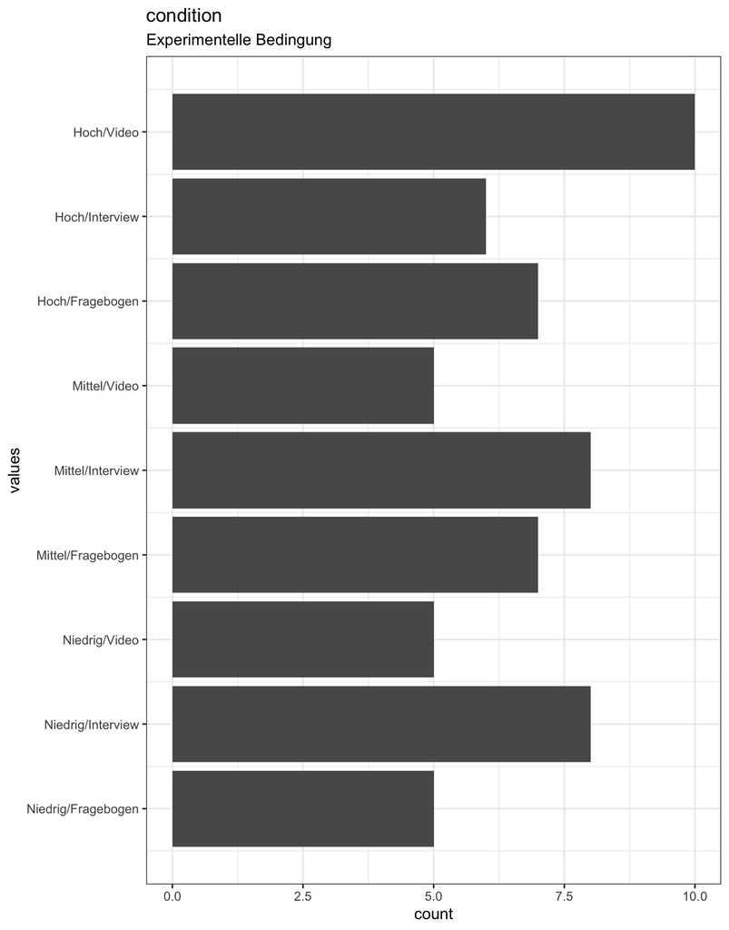

Distribution of values for condition

0 missing values.

#### Summary statistics

| name | label | data_type | n_missing | complete_rate | min | median | max | mean | sd | n_value_labels | hist |
| --- | --- | --- | --- | --- | --- | --- | --- | --- | --- | --- | --- |
| condition | Experimentelle Bedingung | haven_labelled | 0 | 1 | 1 | 5 | 9 | 5.262295 | 2.651425 | 9 | ▇▃▅▅▃▅▃▆ |

#### Value labels

Response choices

| name | value |
| --- | --- |
| Niedrig/Fragebogen | 1 |
| Niedrig/Interview | 2 |
| Niedrig/Video | 3 |
| Mittel/Fragebogen | 4 |
| Mittel/Interview | 5 |
| Mittel/Video | 6 |
| Hoch/Fragebogen | 7 |
| Hoch/Interview | 8 |
| Hoch/Video | 9 |

### experience_participate

Ich habe Erfahrung mit der Teilnahme an wissenschaftlichen Studien, bei denen meine Daten erhoben und für Analysen verwendet wurden.

#### Distribution

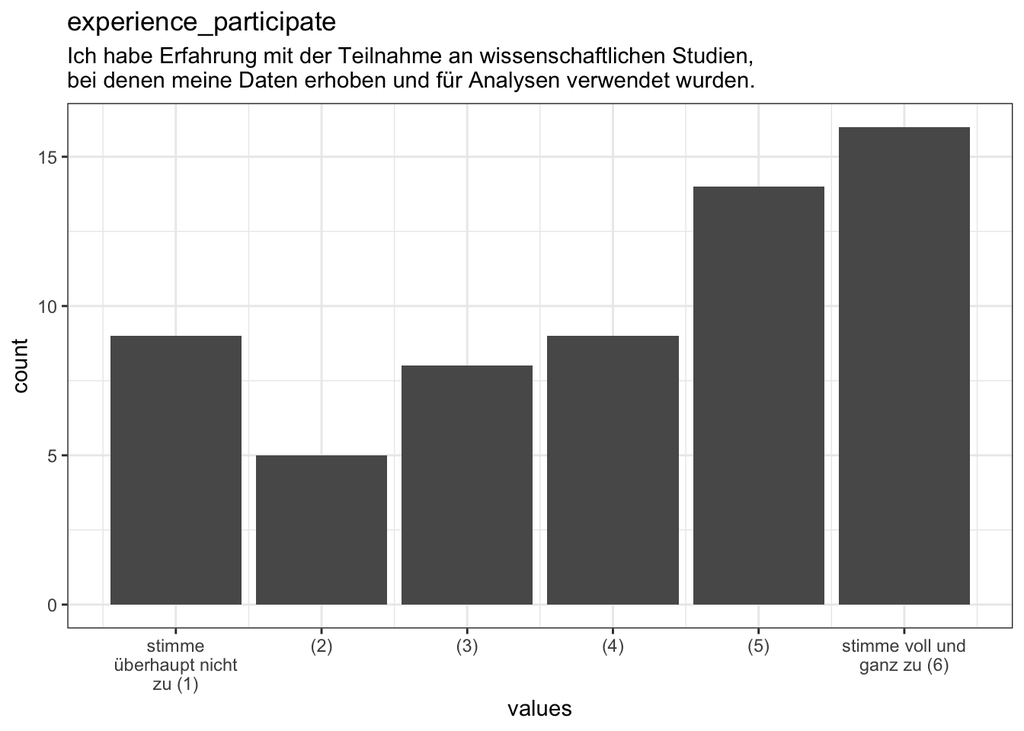

Distribution of values for experience_participate

0 missing values.

#### Summary statistics

| name | label | data_type | n_missing | complete_rate | min | median | max | mean | sd | n_value_labels | hist |
| --- | --- | --- | --- | --- | --- | --- | --- | --- | --- | --- | --- |
| experience_participate | Ich habe Erfahrung mit der Teilnahme an wissenschaftlichen Studien, bei denen meine Daten erhoben und für Analysen verwendet wurden. | haven_labelled | 0 | 1 | 1 | 4 | 6 | 4.016393 | 1.765331 | 6 | ▅▂▁▃▅▁▇▇ |

#### Value labels

Response choices

| name | value |
| --- | --- |
| stimme überhaupt nicht zu (1) | 1 |
| (2) | 2 |
| (3) | 3 |
| (4) | 4 |
| (5) | 5 |
| stimme voll und ganz zu (6) | 6 |

### experience_plan

Ich habe Erfahrung in der Planung von wissenschaftlichen Studien, einschließlich des Umgangs mit und der Speicherung von Daten.

#### Distribution

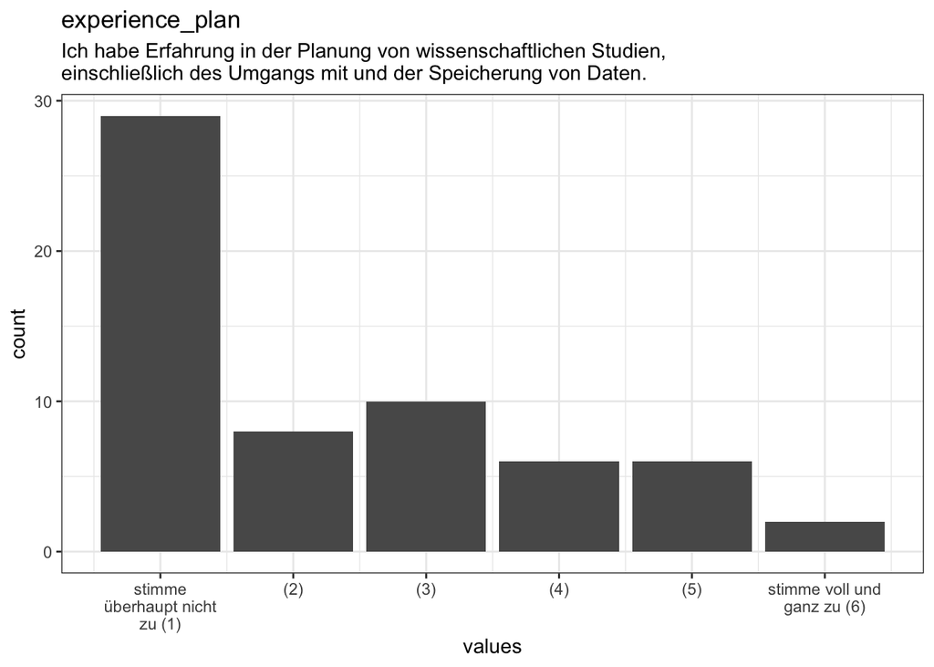

Distribution of values for experience_plan

0 missing values.

#### Summary statistics

| name | label | data_type | n_missing | complete_rate | min | median | max | mean | sd | n_value_labels | hist |
| --- | --- | --- | --- | --- | --- | --- | --- | --- | --- | --- | --- |
| experience_plan | Ich habe Erfahrung in der Planung von wissenschaftlichen Studien, einschließlich des Umgangs mit und der Speicherung von Daten. | haven_labelled | 0 | 1 | 1 | 2 | 6 | 2.311475 | 1.544247 | 6 | ▇▂▁▃▂▁▂▁ |

#### Value labels

Response choices

| name | value |
| --- | --- |
| stimme überhaupt nicht zu (1) | 1 |
| (2) | 2 |
| (3) | 3 |
| (4) | 4 |
| (5) | 5 |
| stimme voll und ganz zu (6) | 6 |

### participateT1_l1

Ich nehme an der beschriebenen Studie teil.

#### Distribution

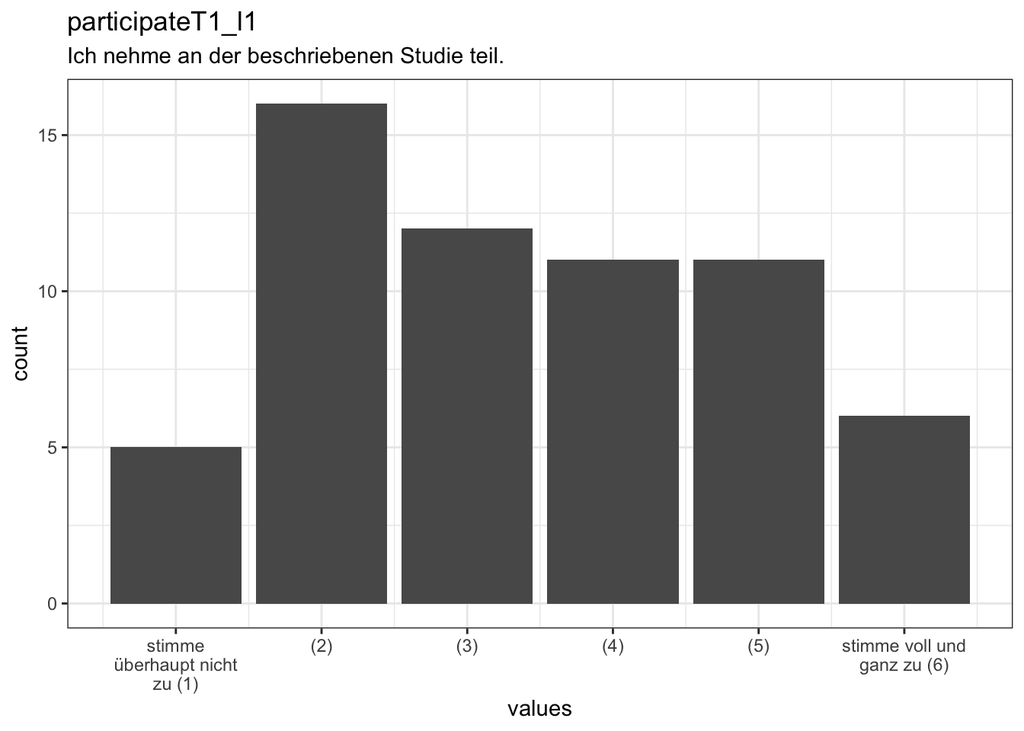

Distribution of values for participateT1_l1

0 missing values.

#### Summary statistics

| name | label | data_type | n_missing | complete_rate | min | median | max | mean | sd | n_value_labels | hist |
| --- | --- | --- | --- | --- | --- | --- | --- | --- | --- | --- | --- |
| participateT1_l1 | Ich nehme an der beschriebenen Studie teil. | haven_labelled | 0 | 1 | 1 | 3 | 6 | 3.409836 | 1.498633 | 6 | ▂▇▁▆▆▁▆▃ |

#### Value labels

Response choices

| name | value |
| --- | --- |
| stimme überhaupt nicht zu (1) | 1 |
| (2) | 2 |
| (3) | 3 |
| (4) | 4 |
| (5) | 5 |
| stimme voll und ganz zu (6) | 6 |

### sensitivityT1_l1

Wie wohl fühlen Sie sich dabei, die Fragen zum Thema der Studie ehrlich zu beantworten?

#### Distribution

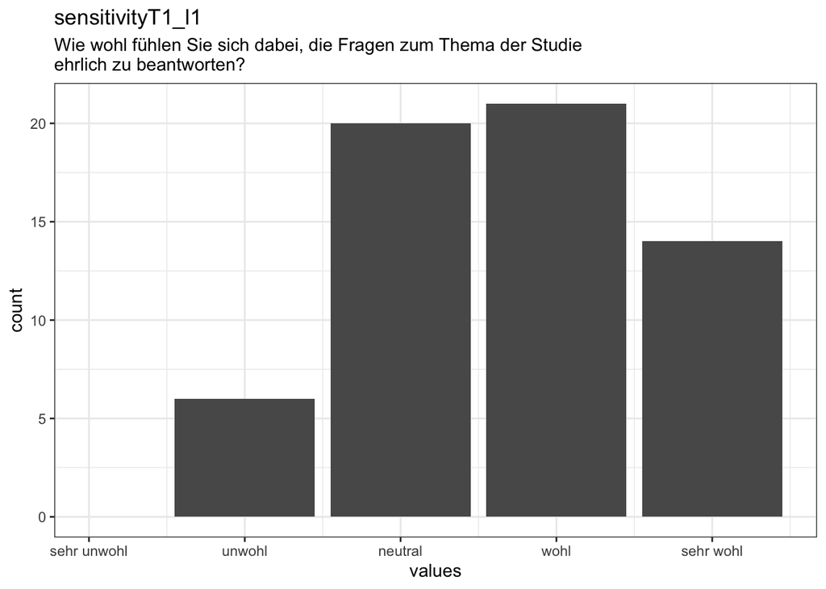

Distribution of values for sensitivityT1_l1

0 missing values.

#### Summary statistics

| name | label | data_type | n_missing | complete_rate | min | median | max | mean | sd | n_value_labels | hist |
| --- | --- | --- | --- | --- | --- | --- | --- | --- | --- | --- | --- |
| sensitivityT1_l1 | Wie wohl fühlen Sie sich dabei, die Fragen zum Thema der Studie ehrlich zu beantworten? | haven_labelled | 0 | 1 | 2 | 4 | 5 | 3.704918 | 0.9370924 | 5 | ▂▁▇▁▁▇▁▅ |

#### Value labels

Response choices

| name | value |
| --- | --- |
| sehr unwohl | 1 |
| unwohl | 2 |
| neutral | 3 |
| wohl | 4 |
| sehr wohl | 5 |

### Scale: elaboration

#### Overview

**Reliability**: Cronbach’s α [95% CI] = 0.86 [0.8;0.91].

**Missing**: 0.

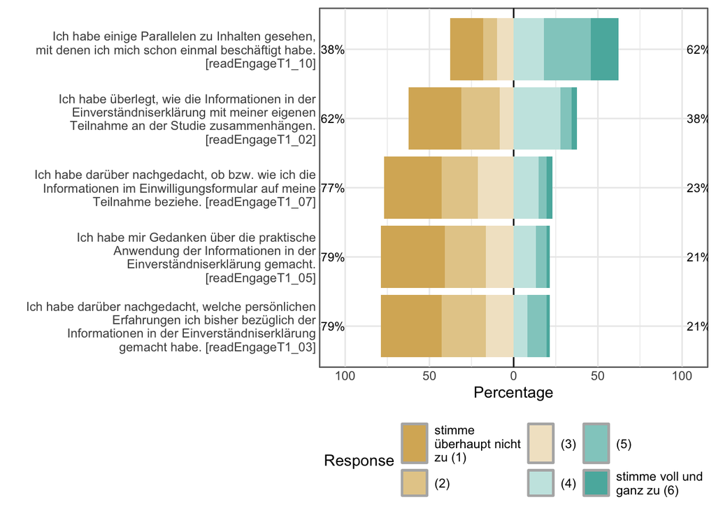

Likert plot of scale elaboration items

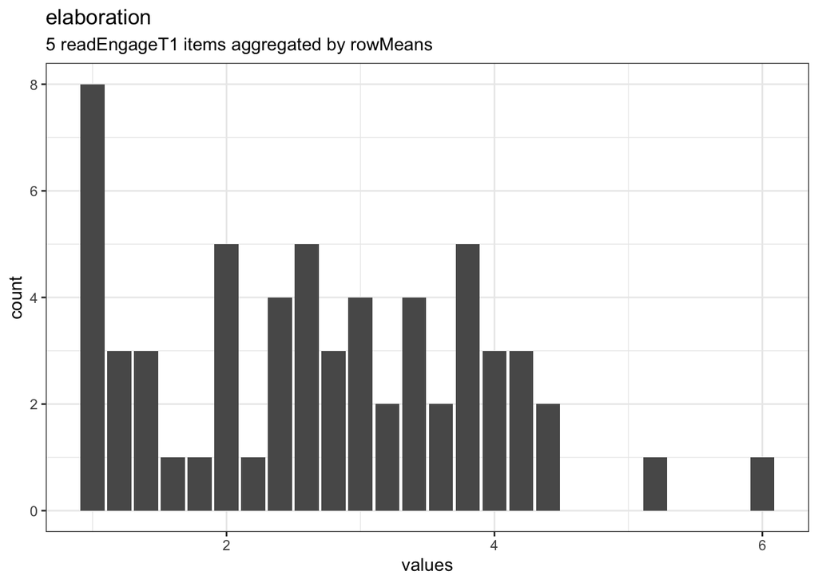

Distribution of scale elaboration

#### Reliability details

###### Reliability

###### 95% Confidence Interval

| lower | estimate | upper |
| --- | --- | --- |
| 0.7986222 | 0.8564847 | 0.9143472 |

|  | raw_alpha | std.alpha | G6(smc) | average_r | S/N | ase | mean | sd | median_r |
| --- | --- | --- | --- | --- | --- | --- | --- | --- | --- |
|  | 0.8564847 | 0.8636585 | 0.8447451 | 0.55887 | 6.334526 | 0.0295217 | 2.708197 | 1.192518 | 0.5740226 |

###### Reliability if an item is dropped:

|  | raw_alpha | std.alpha | G6(smc) | average_r | S/N | alpha se | var.r | med.r |
| --- | --- | --- | --- | --- | --- | --- | --- | --- |
| readEngageT1_02 | 0.8077293 | 0.8169706 | 0.7750039 | 0.5273881 | 4.463603 | 0.0404478 | 0.0048201 | 0.5301419 |
| readEngageT1_03 | 0.8277382 | 0.8382047 | 0.8111382 | 0.5643009 | 5.180649 | 0.0369261 | 0.0141552 | 0.5571901 |
| readEngageT1_05 | 0.8238669 | 0.8329779 | 0.8044927 | 0.5549242 | 4.987233 | 0.0376567 | 0.0125354 | 0.5479630 |
| readEngageT1_07 | 0.8057772 | 0.8150194 | 0.7762150 | 0.5241479 | 4.405973 | 0.0411239 | 0.0078060 | 0.5048793 |
| readEngageT1_10 | 0.8689213 | 0.8688813 | 0.8378562 | 0.6235888 | 6.626677 | 0.0273529 | 0.0039296 | 0.6057949 |

###### Item statistics

|  | n | raw.r | std.r | r.cor | r.drop | mean | sd |
| --- | --- | --- | --- | --- | --- | --- | --- |
| readEngageT1_02 | 61 | 0.8449540 | 0.8513860 | 0.8242548 | 0.7434442 | 2.655738 | 1.493154 |
| readEngageT1_03 | 61 | 0.7900092 | 0.7963211 | 0.7186593 | 0.6681282 | 2.377049 | 1.427865 |
| readEngageT1_05 | 61 | 0.7985574 | 0.8103089 | 0.7440647 | 0.6878215 | 2.311475 | 1.360649 |
| readEngageT1_07 | 61 | 0.8493252 | 0.8562196 | 0.8270650 | 0.7588542 | 2.442623 | 1.396718 |
| readEngageT1_10 | 61 | 0.7358130 | 0.7078782 | 0.5826816 | 0.5443922 | 3.754098 | 1.766878 |

###### Non missing response frequency for each item

|  | 1 | 2 | 3 | 4 | 5 | 6 | miss |
| --- | --- | --- | --- | --- | --- | --- | --- |
| readEngageT1_02 | 0.3114754 | 0.2295082 | 0.0819672 | 0.2786885 | 0.0655738 | 0.0327869 | 0 |
| readEngageT1_03 | 0.3606557 | 0.2622951 | 0.1639344 | 0.0819672 | 0.1147541 | 0.0163934 | 0 |
| readEngageT1_05 | 0.3770492 | 0.2459016 | 0.1639344 | 0.1311475 | 0.0655738 | 0.0163934 | 0 |
| readEngageT1_07 | 0.3442623 | 0.2131148 | 0.2131148 | 0.1475410 | 0.0491803 | 0.0327869 | 0 |
| readEngageT1_10 | 0.1967213 | 0.0819672 | 0.0983607 | 0.1803279 | 0.2786885 | 0.1639344 | 0 |

#### Summary statistics

| name | label | data_type | value_labels | n_missing | complete_rate | min | median | max | mean | sd | n_value_labels | hist |
| --- | --- | --- | --- | --- | --- | --- | --- | --- | --- | --- | --- | --- |
| readEngageT1_02 | Ich habe überlegt, wie die Informationen in der Einverständniserklärung mit meiner eigenen Teilnahme an der Studie zusammenhängen. | haven_labelled | 1. stimme überhaupt nicht zu (1), 2. (2), 3. (3), 4. (4), 5. (5), 6. stimme voll und ganz zu (6) | 0 | 1 | 1 | 2 | 6 | 2.655738 | 1.493154 | 6 | ▇▆▁▂▇▁▂▁ |
| readEngageT1_03 | Ich habe darüber nachgedacht, welche persönlichen Erfahrungen ich bisher bezüglich der Informationen in der Einverständniserklärung gemacht habe. | haven_labelled | 1. stimme überhaupt nicht zu (1), 2. (2), 3. (3), 4. (4), 5. (5), 6. stimme voll und ganz zu (6) | 0 | 1 | 1 | 2 | 6 | 2.377049 | 1.427865 | 6 | ▇▆▁▃▂▁▂▁ |
| readEngageT1_05 | Ich habe mir Gedanken über die praktische Anwendung der Informationen in der Einverständniserklärung gemacht. | haven_labelled | 1. stimme überhaupt nicht zu (1), 2. (2), 3. (3), 4. (4), 5. (5), 6. stimme voll und ganz zu (6) | 0 | 1 | 1 | 2 | 6 | 2.311475 | 1.360649 | 6 | ▇▅▁▃▃▁▂▁ |
| readEngageT1_07 | Ich habe darüber nachgedacht, ob bzw. wie ich die Informationen im Einwilligungsformular auf meine Teilnahme beziehe. | haven_labelled | 1. stimme überhaupt nicht zu (1), 2. (2), 3. (3), 4. (4), 5. (5), 6. stimme voll und ganz zu (6) | 0 | 1 | 1 | 2 | 6 | 2.442623 | 1.396718 | 6 | ▇▅▁▅▃▁▁▁ |
| readEngageT1_10 | Ich habe einige Parallelen zu Inhalten gesehen, mit denen ich mich schon einmal beschäftigt habe. | haven_labelled | 1. stimme überhaupt nicht zu (1), 2. (2), 3. (3), 4. (4), 5. (5), 6. stimme voll und ganz zu (6) | 0 | 1 | 1 | 4 | 6 | 3.754098 | 1.766878 | 6 | ▆▂▁▃▅▁▇▅ |

### Scale: surface_reading

#### Overview

**Reliability**: Cronbach’s α [95% CI] = 0.75 [0.65;0.85].

**Missing**: 0.

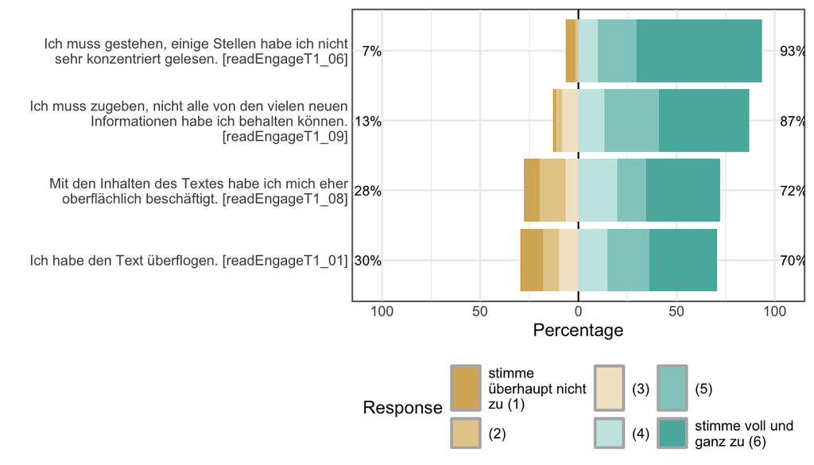

Likert plot of scale surface_reading items

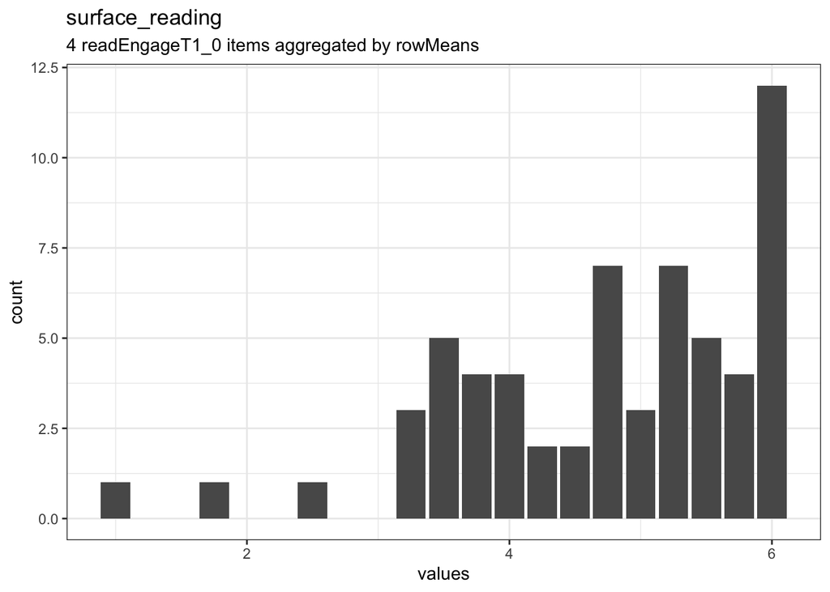

Distribution of scale surface_reading

#### Reliability details

###### Reliability

###### 95% Confidence Interval

| lower | estimate | upper |
| --- | --- | --- |
| 0.6460449 | 0.7461474 | 0.84625 |

|  | raw_alpha | std.alpha | G6(smc) | average_r | S/N | ase | mean | sd | median_r |
| --- | --- | --- | --- | --- | --- | --- | --- | --- | --- |
|  | 0.7461474 | 0.7539478 | 0.7107505 | 0.4337628 | 3.064177 | 0.0510727 | 4.729508 | 1.133114 | 0.4558341 |

###### Reliability if an item is dropped:

|  | raw_alpha | std.alpha | G6(smc) | average_r | S/N | alpha se | var.r | med.r |
| --- | --- | --- | --- | --- | --- | --- | --- | --- |
| readEngageT1_01 | 0.6872302 | 0.7014291 | 0.6114380 | 0.4391777 | 2.349288 | 0.0670603 | 0.0008636 | 0.4502364 |
| readEngageT1_06 | 0.6617520 | 0.6624371 | 0.5842128 | 0.3954551 | 1.962411 | 0.0708217 | 0.0134883 | 0.4058648 |
| readEngageT1_08 | 0.6583625 | 0.6755950 | 0.6011270 | 0.4097470 | 2.082567 | 0.0740042 | 0.0144639 | 0.4502364 |
| readEngageT1_09 | 0.7338856 | 0.7429377 | 0.6591785 | 0.4906714 | 2.890107 | 0.0569072 | 0.0006418 | 0.5045432 |

###### Item statistics

|  | n | raw.r | std.r | r.cor | r.drop | mean | sd |
| --- | --- | --- | --- | --- | --- | --- | --- |
| readEngageT1_01 | 61 | 0.7892652 | 0.7531457 | 0.6392384 | 0.5518980 | 4.295082 | 1.735360 |
| readEngageT1_06 | 61 | 0.7690020 | 0.7963783 | 0.7021930 | 0.6075200 | 5.295082 | 1.269439 |
| readEngageT1_08 | 61 | 0.8099324 | 0.7822466 | 0.6753910 | 0.5936278 | 4.327869 | 1.709984 |
| readEngageT1_09 | 61 | 0.6545245 | 0.7022291 | 0.5410219 | 0.4531346 | 5.000000 | 1.224745 |

###### Non missing response frequency for each item

|  | 1 | 2 | 3 | 4 | 5 | 6 | miss |
| --- | --- | --- | --- | --- | --- | --- | --- |
| readEngageT1_01 | 0.1147541 | 0.0819672 | 0.0983607 | 0.1475410 | 0.2131148 | 0.3442623 | 0 |
| readEngageT1_06 | 0.0491803 | 0.0163934 | 0.0000000 | 0.0983607 | 0.1967213 | 0.6393443 | 0 |
| readEngageT1_08 | 0.0819672 | 0.1311475 | 0.0655738 | 0.1967213 | 0.1475410 | 0.3770492 | 0 |
| readEngageT1_09 | 0.0163934 | 0.0327869 | 0.0819672 | 0.1311475 | 0.2786885 | 0.4590164 | 0 |

#### Summary statistics

| name | label | data_type | value_labels | n_missing | complete_rate | min | median | max | mean | sd | n_value_labels | hist |
| --- | --- | --- | --- | --- | --- | --- | --- | --- | --- | --- | --- | --- |
| readEngageT1_01 | Ich habe den Text überflogen. | haven_labelled | 1. stimme überhaupt nicht zu (1), 2. (2), 3. (3), 4. (4), 5. (5), 6. stimme voll und ganz zu (6) | 0 | 1 | 1 | 5 | 6 | 4.295082 | 1.735360 | 6 | ▂▂▁▂▃▁▅▇ |
| readEngageT1_06 | Ich muss gestehen, einige Stellen habe ich nicht sehr konzentriert gelesen. | haven_labelled | 1. stimme überhaupt nicht zu (1), 2. (2), 3. (3), 4. (4), 5. (5), 6. stimme voll und ganz zu (6) | 0 | 1 | 1 | 6 | 6 | 5.295082 | 1.269439 | 6 | ▁▁▁▁▁▁▂▇ |
| readEngageT1_08 | Mit den Inhalten des Textes habe ich mich eher oberflächlich beschäftigt. | haven_labelled | 1. stimme überhaupt nicht zu (1), 2. (2), 3. (3), 4. (4), 5. (5), 6. stimme voll und ganz zu (6) | 0 | 1 | 1 | 5 | 6 | 4.327869 | 1.709984 | 6 | ▂▃▁▂▅▁▃▇ |
| readEngageT1_09 | Ich muss zugeben, nicht alle von den vielen neuen Informationen habe ich behalten können. | haven_labelled | 1. stimme überhaupt nicht zu (1), 2. (2), 3. (3), 4. (4), 5. (5), 6. stimme voll und ganz zu (6) | 0 | 1 | 1 | 5 | 6 | 5.000000 | 1.224745 | 6 | ▁▁▁▂▂▁▅▇ |

### Scale: RecallT1

#### Overview

**Reliability**: Cronbach’s α [95% CI] = -0.36 [-0.85;0.13].

**Missing**: 0.

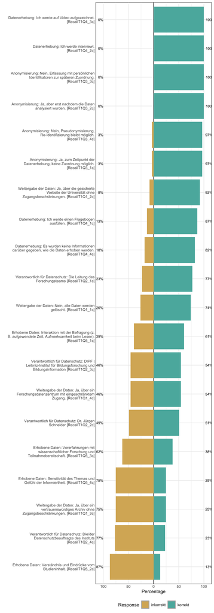

Likert plot of scale RecallT1 items

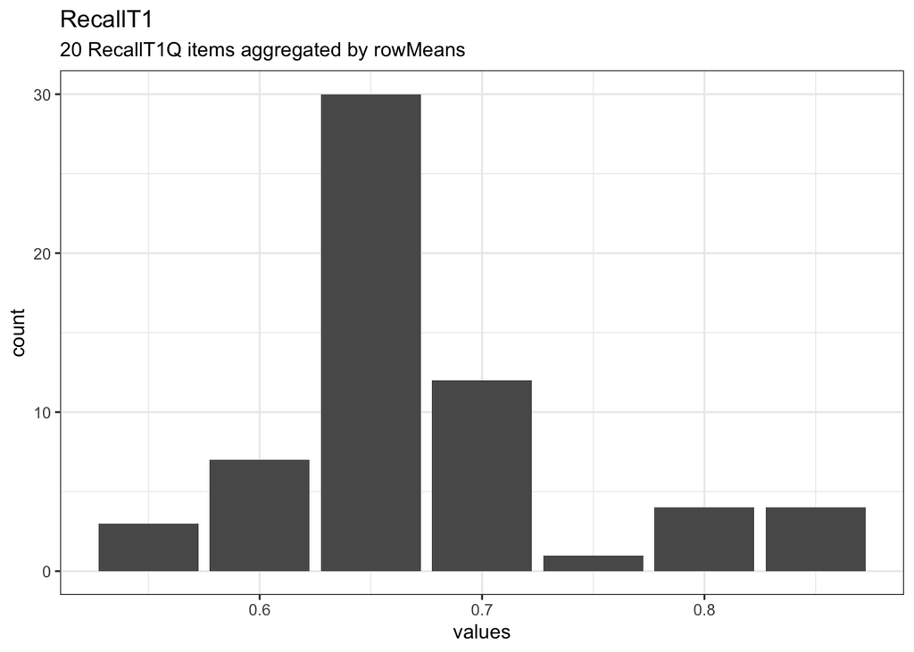

Distribution of scale RecallT1

#### Reliability details

###### Reliability

###### 95% Confidence Interval

| lower | estimate | upper |
| --- | --- | --- |
| -0.8454043 | -0.3571905 | 0.1310233 |

|  | raw_alpha | std.alpha | G6(smc) | average_r | S/N | ase | mean | sd | median_r |
| --- | --- | --- | --- | --- | --- | --- | --- | --- | --- |
|  | -0.3571905 | -0.0863098 | 0.3672698 | -0.0049905 | -0.0794523 | 0.2490887 | 0.6737705 | 0.0710672 | -0.0240757 |

###### Reliability if an item is dropped:

|  | raw_alpha | std.alpha | G6(smc) | average_r | S/N | alpha se | var.r | med.r |
| --- | --- | --- | --- | --- | --- | --- | --- | --- |
| RecallT1Q1_1c | -0.3922280 | -0.1072763 | 0.2762307 | -0.0065009 | -0.0968831 | 0.2539925 | 0.0410412 | -0.0319530 |
| RecallT1Q1_2c | -0.2755824 | 0.0085010 | 0.4274626 | 0.0005713 | 0.0085739 | 0.2344064 | 0.0458539 | -0.0042083 |
| RecallT1Q1_3c | -0.9244550 | -0.3568927 | 0.1690010 | -0.0178478 | -0.2630221 | 0.3620020 | 0.0432544 | -0.0448868 |
| RecallT1Q1_4c | -0.5040152 | -0.1318428 | 0.2670839 | -0.0078264 | -0.1164851 | 0.2755103 | 0.0428845 | -0.0465856 |
| RecallT1Q2_1c | -0.5042419 | -0.2421148 | 0.2556223 | -0.0131659 | -0.1949215 | 0.2791888 | 0.0421126 | -0.0319530 |
| RecallT1Q2_2c | -0.0195249 | 0.1209548 | 0.4527063 | 0.0090898 | 0.1375979 | 0.1891843 | 0.0428651 | -0.0042083 |
| RecallT1Q2_3c | -0.1586792 | 0.0616708 | 0.4266033 | 0.0043625 | 0.0657240 | 0.2141151 | 0.0445992 | -0.0189323 |
| RecallT1Q2_4c | -0.4087754 | -0.0977240 | 0.3659671 | -0.0059704 | -0.0890242 | 0.2579881 | 0.0457090 | -0.0189323 |
| RecallT1Q3_1c | -0.4148547 | -0.3011555 | 0.3032701 | -0.0156720 | -0.2314523 | 0.2601395 | 0.0353671 | -0.0292191 |
| RecallT1Q3_4c | -0.4148547 | -0.3011555 | 0.3032701 | -0.0156720 | -0.2314523 | 0.2601395 | 0.0353671 | -0.0292191 |
| RecallT1Q4_1c | -0.3520193 | -0.0690805 | 0.3163048 | -0.0043264 | -0.0646167 | 0.2472335 | 0.0390782 | -0.0141502 |
| RecallT1Q4_4c | -0.3425780 | -0.0737532 | 0.3080878 | -0.0046002 | -0.0686873 | 0.2450587 | 0.0375002 | -0.0141502 |
| RecallT1Q5_1c | -0.1152017 | 0.0792618 | 0.4160587 | 0.0057063 | 0.0860850 | 0.2064123 | 0.0422755 | -0.0189323 |
| RecallT1Q5_2c | -0.3616944 | -0.1019364 | 0.3654394 | -0.0062054 | -0.0925066 | 0.2495401 | 0.0458193 | -0.0353881 |
| RecallT1Q5_3c | -0.1885154 | 0.0092161 | 0.3741489 | 0.0006197 | 0.0093018 | 0.2195128 | 0.0423813 | -0.0292191 |
| RecallT1Q5_4c | -0.2417509 | -0.0374293 | 0.3797589 | -0.0024111 | -0.0360789 | 0.2287689 | 0.0441086 | -0.0189323 |

###### Item statistics

|  | n | raw.r | std.r | r.cor | r.drop | mean | sd |
| --- | --- | --- | --- | --- | --- | --- | --- |
| RecallT1Q1_1c | 61 | 0.3068508 | 0.2816792 | 0.3236297 | -0.0054644 | 0.7377049 | 0.4435328 |
| RecallT1Q1_2c | 61 | 0.0159849 | 0.0886713 | -0.2044427 | -0.1758526 | 0.9180328 | 0.2765913 |
| RecallT1Q1_3c | 61 | 0.6986228 | 0.5913515 | 0.7833187 | 0.4815630 | 0.2459016 | 0.4341942 |
| RecallT1Q1_4c | 61 | 0.4273439 | 0.3178563 | 0.3707844 | 0.0814004 | 0.5409836 | 0.5024530 |
| RecallT1Q2_1c | 61 | 0.4053077 | 0.4635758 | 0.5174793 | 0.1162447 | 0.7704918 | 0.4240064 |
| RecallT1Q2_2c | 61 | -0.0869468 | -0.1438114 | -0.4706620 | -0.4052470 | 0.5081967 | 0.5040817 |
| RecallT1Q2_3c | 61 | 0.1006190 | -0.0147964 | -0.2885117 | -0.2463434 | 0.5409836 | 0.5024530 |
| RecallT1Q2_4c | 61 | 0.3137281 | 0.2672017 | 0.1063448 | 0.0162319 | 0.2295082 | 0.4240064 |
| RecallT1Q3_1c | 61 | 0.2580099 | 0.5319714 | 0.4489128 | 0.1350475 | 0.9672131 | 0.1795562 |
| RecallT1Q3_4c | 61 | 0.2580099 | 0.5319714 | 0.4489128 | 0.1350475 | 0.9672131 | 0.1795562 |
| RecallT1Q4_1c | 61 | 0.1999312 | 0.2223358 | 0.2515346 | -0.0403163 | 0.8688525 | 0.3403630 |
| RecallT1Q4_4c | 61 | 0.2186843 | 0.2298081 | 0.2758215 | -0.0553072 | 0.8196721 | 0.3876509 |
| RecallT1Q5_1c | 61 | 0.0335623 | -0.0514695 | -0.2934518 | -0.2988529 | 0.6065574 | 0.4925677 |
| RecallT1Q5_2c | 61 | 0.2134859 | 0.2736151 | 0.1108928 | -0.0265834 | 0.1311475 | 0.3403630 |
| RecallT1Q5_3c | 61 | 0.1215523 | 0.0873484 | -0.0518381 | -0.2185053 | 0.3770492 | 0.4886694 |
| RecallT1Q5_4c | 61 | 0.1314898 | 0.1700629 | 0.0028897 | -0.1728730 | 0.2459016 | 0.4341942 |

###### Non missing response frequency for each item

|  | 0 | 1 | miss |
| --- | --- | --- | --- |
| RecallT1Q1_1c | 0.2622951 | 0.7377049 | 0 |
| RecallT1Q1_2c | 0.0819672 | 0.9180328 | 0 |
| RecallT1Q1_3c | 0.7540984 | 0.2459016 | 0 |
| RecallT1Q1_4c | 0.4590164 | 0.5409836 | 0 |
| RecallT1Q2_1c | 0.2295082 | 0.7704918 | 0 |
| RecallT1Q2_2c | 0.4918033 | 0.5081967 | 0 |
| RecallT1Q2_3c | 0.4590164 | 0.5409836 | 0 |
| RecallT1Q2_4c | 0.7704918 | 0.2295082 | 0 |
| RecallT1Q3_1c | 0.0327869 | 0.9672131 | 0 |
| RecallT1Q3_4c | 0.0327869 | 0.9672131 | 0 |
| RecallT1Q4_1c | 0.1311475 | 0.8688525 | 0 |
| RecallT1Q4_4c | 0.1803279 | 0.8196721 | 0 |
| RecallT1Q5_1c | 0.3934426 | 0.6065574 | 0 |
| RecallT1Q5_2c | 0.8688525 | 0.1311475 | 0 |
| RecallT1Q5_3c | 0.6229508 | 0.3770492 | 0 |
| RecallT1Q5_4c | 0.7540984 | 0.2459016 | 0 |

#### Summary statistics

| name | label | data_type | value_labels | n_missing | complete_rate | min | median | max | mean | sd | n_value_labels | hist |
| --- | --- | --- | --- | --- | --- | --- | --- | --- | --- | --- | --- | --- |
| RecallT1Q1_1c | Weitergabe der Daten: Nein, alle Daten werden gelöscht. | haven_labelled | 0. inkorrekt, 1. korrekt | 0 | 1 | 0 | 1 | 1 | 0.7377049 | 0.4435328 | 2 | ▃▁▁▁▁▁▁▇ |
| RecallT1Q1_2c | Weitergabe der Daten: Ja, über die gesicherte Website der Universität ohne Zugangsbeschränkungen. | haven_labelled | 0. inkorrekt, 1. korrekt | 0 | 1 | 0 | 1 | 1 | 0.9180328 | 0.2765913 | 2 | ▁▁▁▁▁▁▁▇ |
| RecallT1Q1_3c | Weitergabe der Daten: Ja, über ein vertrauenswürdiges Archiv ohne Zugangsbeschränkungen. | haven_labelled | 0. inkorrekt, 1. korrekt | 0 | 1 | 0 | 0 | 1 | 0.2459016 | 0.4341942 | 2 | ▇▁▁▁▁▁▁▂ |
| RecallT1Q1_4c | Weitergabe der Daten: Ja, über ein Forschungsdatenzentrum mit eingeschränktem Zugang. | haven_labelled | 0. inkorrekt, 1. korrekt | 0 | 1 | 0 | 1 | 1 | 0.5409836 | 0.5024530 | 2 | ▇▁▁▁▁▁▁▇ |
| RecallT1Q2_1c | Verantwortlich für Datenschutz: Die Leitung des Forschungsteams | haven_labelled | 0. inkorrekt, 1. korrekt | 0 | 1 | 0 | 1 | 1 | 0.7704918 | 0.4240064 | 2 | ▂▁▁▁▁▁▁▇ |
| RecallT1Q2_2c | Verantwortlich für Datenschutz: Dr. Jürgen Schneider | haven_labelled | 0. inkorrekt, 1. korrekt | 0 | 1 | 0 | 1 | 1 | 0.5081967 | 0.5040817 | 2 | ▇▁▁▁▁▁▁▇ |
| RecallT1Q2_3c | Verantwortlich für Datenschutz: DIPF \| Leibniz-Institut für Bildungsforschung und Bildungsinformation | haven_labelled | 0. inkorrekt, 1. korrekt | 0 | 1 | 0 | 1 | 1 | 0.5409836 | 0.5024530 | 2 | ▇▁▁▁▁▁▁▇ |
| RecallT1Q2_4c | Verantwortlich für Datenschutz: Die/der Datenschutzbeauftragte des Instituts | haven_labelled | 0. inkorrekt, 1. korrekt | 0 | 1 | 0 | 0 | 1 | 0.2295082 | 0.4240064 | 2 | ▇▁▁▁▁▁▁▂ |
| RecallT1Q3_1c | Anonymisierung: Ja, zum Zeitpunkt der Datenerhebung, keine Zuordnung möglich. | haven_labelled | 0. inkorrekt, 1. korrekt | 0 | 1 | 0 | 1 | 1 | 0.9672131 | 0.1795562 | 2 | ▁▁▁▁▁▁▁▇ |
| RecallT1Q3_2c | Anonymisierung: Ja, aber erst nachdem die Daten analysiert wurden. | haven_labelled | 0. inkorrekt, 1. korrekt | 0 | 1 | 1 | 1 | 1 | 1.0000000 | 0.0000000 | 2 | ▁▁▁▇▁▁▁▁ |
| RecallT1Q3_3c | Anonymisierung: Nein, Erfassung mit persönlichen Identifikatoren zur späteren Zuordnung. | haven_labelled | 0. inkorrekt, 1. korrekt | 0 | 1 | 1 | 1 | 1 | 1.0000000 | 0.0000000 | 2 | ▁▁▁▇▁▁▁▁ |
| RecallT1Q3_4c | Anonymisierung: Nein, Pseudonymisierung, Re-Identifizierung bleibt möglich. | haven_labelled | 0. inkorrekt, 1. korrekt | 0 | 1 | 0 | 1 | 1 | 0.9672131 | 0.1795562 | 2 | ▁▁▁▁▁▁▁▇ |
| RecallT1Q4_1c | Datenerhebung: Ich werde einen Fragebogen ausfüllen. | haven_labelled | 0. inkorrekt, 1. korrekt | 0 | 1 | 0 | 1 | 1 | 0.8688525 | 0.3403630 | 2 | ▁▁▁▁▁▁▁▇ |
| RecallT1Q4_2c | Datenerhebung: Ich werde interviewt. | haven_labelled | 0. inkorrekt, 1. korrekt | 0 | 1 | 1 | 1 | 1 | 1.0000000 | 0.0000000 | 2 | ▁▁▁▇▁▁▁▁ |
| RecallT1Q4_3c | Datenerhebung: Ich werde auf Video aufgezeichnet. | haven_labelled | 0. inkorrekt, 1. korrekt | 0 | 1 | 1 | 1 | 1 | 1.0000000 | 0.0000000 | 2 | ▁▁▁▇▁▁▁▁ |
| RecallT1Q4_4c | Datenerhebung: Es wurden keine Informationen darüber gegeben, wie die Daten erhoben werden. | haven_labelled | 0. inkorrekt, 1. korrekt | 0 | 1 | 0 | 1 | 1 | 0.8196721 | 0.3876509 | 2 | ▂▁▁▁▁▁▁▇ |
| RecallT1Q5_1c | Erhobene Daten: Interaktion mit der Befragung (z. B. aufgewendete Zeit, Aufmerksamkeit beim Lesen). | haven_labelled | 0. inkorrekt, 1. korrekt | 0 | 1 | 0 | 1 | 1 | 0.6065574 | 0.4925677 | 2 | ▅▁▁▁▁▁▁▇ |
| RecallT1Q5_2c | Erhobene Daten: Verständnis und Eindrücke vom Studieninhalt. | haven_labelled | 0. inkorrekt, 1. korrekt | 0 | 1 | 0 | 0 | 1 | 0.1311475 | 0.3403630 | 2 | ▇▁▁▁▁▁▁▁ |
| RecallT1Q5_3c | Erhobene Daten: Vorerfahrungen mit wissenschaftlicher Forschung und Teilnahmebereitschaft. | haven_labelled | 0. inkorrekt, 1. korrekt | 0 | 1 | 0 | 0 | 1 | 0.3770492 | 0.4886694 | 2 | ▇▁▁▁▁▁▁▅ |
| RecallT1Q5_4c | Erhobene Daten: Sensitivität des Themas und Gefühl der Informiertheit. | haven_labelled | 0. inkorrekt, 1. korrekt | 0 | 1 | 0 | 0 | 1 | 0.2459016 | 0.4341942 | 2 | ▇▁▁▁▁▁▁▂ |

### Scale: benefits

#### Overview

**Reliability**: Cronbach’s α [95% CI] = 0.83 [0.77;0.9].

**Missing**: 0.

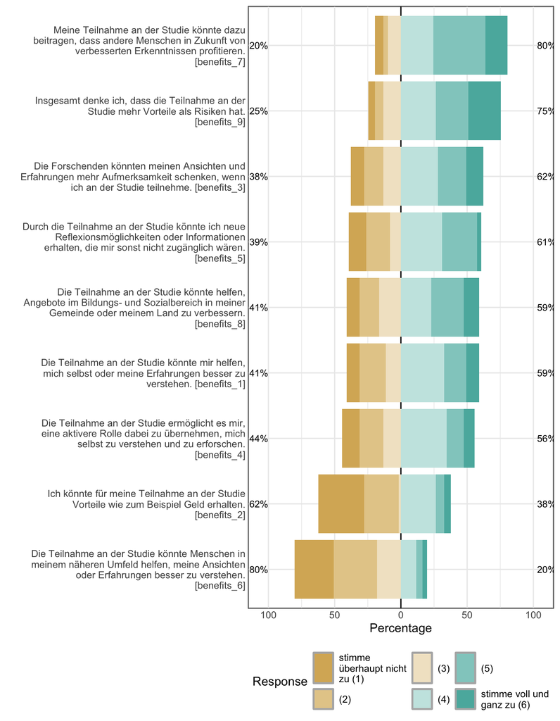

Likert plot of scale benefits items

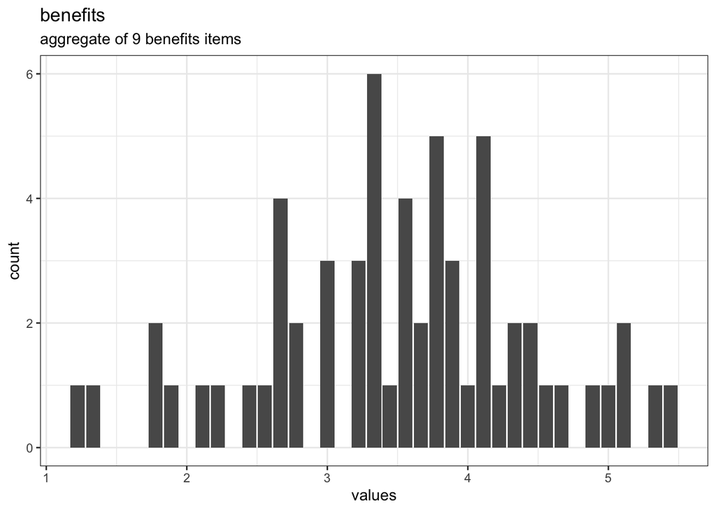

Distribution of scale benefits

#### Reliability details

###### Reliability

###### 95% Confidence Interval

| lower | estimate | upper |
| --- | --- | --- |
| 0.770356 | 0.8328716 | 0.8953873 |

|  | raw_alpha | std.alpha | G6(smc) | average_r | S/N | ase | mean | sd | median_r |
| --- | --- | --- | --- | --- | --- | --- | --- | --- | --- |
|  | 0.8328716 | 0.8356184 | 0.8621389 | 0.3609501 | 5.083406 | 0.0318957 | 3.51184 | 0.9543659 | 0.3563297 |

###### Reliability if an item is dropped:

|  | raw_alpha | std.alpha | G6(smc) | average_r | S/N | alpha se | var.r | med.r |
| --- | --- | --- | --- | --- | --- | --- | --- | --- |
| benefits_1 | 0.7948961 | 0.7991581 | 0.8215401 | 0.3321669 | 3.979041 | 0.0396356 | 0.0276543 | 0.3429654 |
| benefits_2 | 0.8554360 | 0.8555872 | 0.8742571 | 0.4254769 | 5.924594 | 0.0279947 | 0.0199477 | 0.4021315 |
| benefits_3 | 0.8248021 | 0.8280507 | 0.8556537 | 0.3757640 | 4.815666 | 0.0337083 | 0.0373128 | 0.3773086 |
| benefits_4 | 0.8028051 | 0.8067047 | 0.8171100 | 0.3428311 | 4.173431 | 0.0380037 | 0.0239833 | 0.3486825 |
| benefits_5 | 0.7971065 | 0.8005470 | 0.8295831 | 0.3340943 | 4.013713 | 0.0392154 | 0.0279003 | 0.3486825 |
| benefits_6 | 0.8182944 | 0.8214966 | 0.8504730 | 0.3651869 | 4.602134 | 0.0351010 | 0.0362208 | 0.3529792 |
| benefits_7 | 0.8098979 | 0.8122178 | 0.8319134 | 0.3509295 | 4.325317 | 0.0365777 | 0.0314932 | 0.3486825 |
| benefits_8 | 0.8055634 | 0.8087753 | 0.8319802 | 0.3458414 | 4.229449 | 0.0374024 | 0.0346673 | 0.3529792 |
| benefits_9 | 0.8252480 | 0.8283512 | 0.8518992 | 0.3762596 | 4.825848 | 0.0335818 | 0.0365539 | 0.3942388 |

###### Item statistics

|  | n | raw.r | std.r | r.cor | r.drop | mean | sd |
| --- | --- | --- | --- | --- | --- | --- | --- |
| benefits_1 | 61 | 0.7961457 | 0.7934826 | 0.7977795 | 0.7179392 | 3.557377 | 1.477888 |
| benefits_2 | 61 | 0.3674410 | 0.3517857 | 0.2183057 | 0.1942042 | 2.590164 | 1.574559 |
| benefits_3 | 61 | 0.5960883 | 0.5871093 | 0.5023950 | 0.4623675 | 3.754098 | 1.523764 |
| benefits_4 | 61 | 0.7450695 | 0.7430020 | 0.7519329 | 0.6517732 | 3.409836 | 1.476223 |
| benefits_5 | 61 | 0.7824128 | 0.7843590 | 0.7737103 | 0.7006494 | 3.491803 | 1.467685 |
| benefits_6 | 61 | 0.6267444 | 0.6371778 | 0.5656052 | 0.5177672 | 2.393443 | 1.332650 |
| benefits_7 | 61 | 0.6941806 | 0.7046672 | 0.6754655 | 0.5996697 | 4.360656 | 1.329571 |
| benefits_8 | 61 | 0.7277212 | 0.7287526 | 0.6977242 | 0.6262804 | 3.721312 | 1.518016 |
| benefits_9 | 61 | 0.5774321 | 0.5847635 | 0.5093368 | 0.4515336 | 4.327869 | 1.410925 |

###### Non missing response frequency for each item

|  | 1 | 2 | 3 | 4 | 5 | 6 | miss |
| --- | --- | --- | --- | --- | --- | --- | --- |
| benefits_1 | 0.0983607 | 0.1967213 | 0.1147541 | 0.3278689 | 0.1639344 | 0.0983607 | 0 |
| benefits_2 | 0.3442623 | 0.2622951 | 0.0163934 | 0.2622951 | 0.0655738 | 0.0491803 | 0 |
| benefits_3 | 0.0983607 | 0.1475410 | 0.1311475 | 0.2786885 | 0.2131148 | 0.1311475 | 0 |
| benefits_4 | 0.1311475 | 0.1803279 | 0.1311475 | 0.3442623 | 0.1311475 | 0.0819672 | 0 |
| benefits_5 | 0.1311475 | 0.1803279 | 0.0819672 | 0.3114754 | 0.2622951 | 0.0327869 | 0 |
| benefits_6 | 0.2950820 | 0.3278689 | 0.1803279 | 0.1147541 | 0.0491803 | 0.0327869 | 0 |
| benefits_7 | 0.0655738 | 0.0327869 | 0.0983607 | 0.2459016 | 0.3934426 | 0.1639344 | 0 |
| benefits_8 | 0.0983607 | 0.1475410 | 0.1639344 | 0.2295082 | 0.2459016 | 0.1147541 | 0 |
| benefits_9 | 0.0491803 | 0.0655738 | 0.1311475 | 0.2622951 | 0.2459016 | 0.2459016 | 0 |

#### Summary statistics

| name | label | data_type | value_labels | n_missing | complete_rate | min | median | max | mean | sd | n_value_labels | hist |
| --- | --- | --- | --- | --- | --- | --- | --- | --- | --- | --- | --- | --- |
| benefits_1 | Die Teilnahme an der Studie könnte mir helfen, mich selbst oder meine Erfahrungen besser zu verstehen. | haven_labelled | 1. stimme überhaupt nicht zu (1), 2. (2), 3. (3), 4. (4), 5. (5), 6. stimme voll und ganz zu (6) | 0 | 1 | 1 | 4 | 6 | 3.557377 | 1.477888 | 6 | ▂▅▁▃▇▁▃▂ |
| benefits_2 | Ich könnte für meine Teilnahme an der Studie Vorteile wie zum Beispiel Geld erhalten. | haven_labelled | 1. stimme überhaupt nicht zu (1), 2. (2), 3. (3), 4. (4), 5. (5), 6. stimme voll und ganz zu (6) | 0 | 1 | 1 | 2 | 6 | 2.590164 | 1.574559 | 6 | ▇▆▁▁▆▁▂▁ |
| benefits_3 | Die Forschenden könnten meinen Ansichten und Erfahrungen mehr Aufmerksamkeit schenken, wenn ich an der Studie teilnehme. | haven_labelled | 1. stimme überhaupt nicht zu (1), 2. (2), 3. (3), 4. (4), 5. (5), 6. stimme voll und ganz zu (6) | 0 | 1 | 1 | 4 | 6 | 3.754098 | 1.523764 | 6 | ▃▅▁▃▇▁▆▃ |
| benefits_4 | Die Teilnahme an der Studie ermöglicht es mir, eine aktivere Rolle dabei zu übernehmen, mich selbst zu verstehen und zu erforschen. | haven_labelled | 1. stimme überhaupt nicht zu (1), 2. (2), 3. (3), 4. (4), 5. (5), 6. stimme voll und ganz zu (6) | 0 | 1 | 1 | 4 | 6 | 3.409836 | 1.476223 | 6 | ▃▅▁▃▇▁▃▂ |
| benefits_5 | Durch die Teilnahme an der Studie könnte ich neue Reflexionsmöglichkeiten oder Informationen erhalten, die mir sonst nicht zugänglich wären. | haven_labelled | 1. stimme überhaupt nicht zu (1), 2. (2), 3. (3), 4. (4), 5. (5), 6. stimme voll und ganz zu (6) | 0 | 1 | 1 | 4 | 6 | 3.491803 | 1.467685 | 6 | ▃▅▁▂▇▁▇▁ |
| benefits_6 | Die Teilnahme an der Studie könnte Menschen in meinem näheren Umfeld helfen, meine Ansichten oder Erfahrungen besser zu verstehen. | haven_labelled | 1. stimme überhaupt nicht zu (1), 2. (2), 3. (3), 4. (4), 5. (5), 6. stimme voll und ganz zu (6) | 0 | 1 | 1 | 2 | 6 | 2.393443 | 1.332650 | 6 | ▇▇▁▅▃▁▁▁ |
| benefits_7 | Meine Teilnahme an der Studie könnte dazu beitragen, dass andere Menschen in Zukunft von verbesserten Erkenntnissen profitieren. | haven_labelled | 1. stimme überhaupt nicht zu (1), 2. (2), 3. (3), 4. (4), 5. (5), 6. stimme voll und ganz zu (6) | 0 | 1 | 1 | 5 | 6 | 4.360656 | 1.329571 | 6 | ▁▁▁▂▅▁▇▃ |
| benefits_8 | Die Teilnahme an der Studie könnte helfen, Angebote im Bildungs- und Sozialbereich in meiner Gemeinde oder meinem Land zu verbessern. | haven_labelled | 1. stimme überhaupt nicht zu (1), 2. (2), 3. (3), 4. (4), 5. (5), 6. stimme voll und ganz zu (6) | 0 | 1 | 1 | 4 | 6 | 3.721312 | 1.518016 | 6 | ▃▅▁▅▇▁▇▃ |
| benefits_9 | Insgesamt denke ich, dass die Teilnahme an der Studie mehr Vorteile als Risiken hat. | haven_labelled | 1. stimme überhaupt nicht zu (1), 2. (2), 3. (3), 4. (4), 5. (5), 6. stimme voll und ganz zu (6) | 0 | 1 | 1 | 4 | 6 | 4.327869 | 1.410925 | 6 | ▂▂▁▃▇▁▇▇ |

### Scale: EpistemicTrust

#### Overview

**Reliability**: Cronbach’s α [95% CI] = 0.92 [0.89;0.95].

**Missing**: 0.

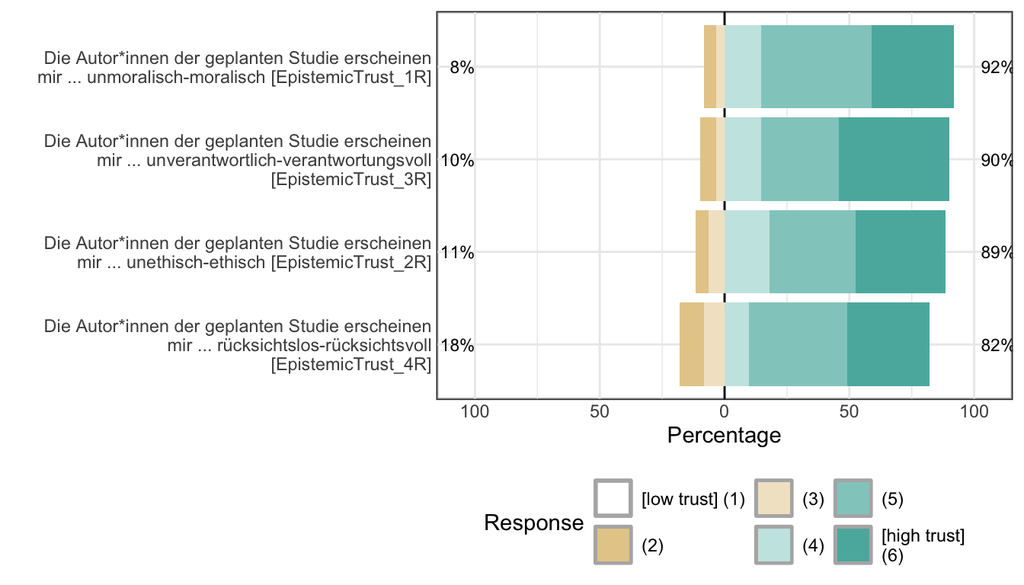

Likert plot of scale EpistemicTrust items

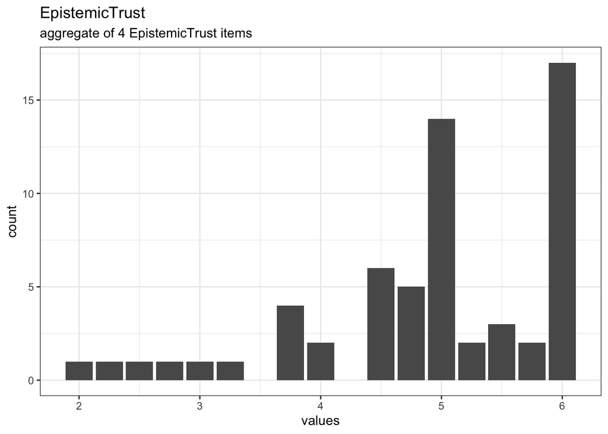

Distribution of scale EpistemicTrust

#### Reliability details

###### Reliability

###### 95% Confidence Interval

| lower | estimate | upper |
| --- | --- | --- |
| 0.8855829 | 0.9191372 | 0.9526915 |

|  | raw_alpha | std.alpha | G6(smc) | average_r | S/N | ase | mean | sd | median_r |
| --- | --- | --- | --- | --- | --- | --- | --- | --- | --- |
|  | 0.9191372 | 0.9223748 | 0.9074051 | 0.7481492 | 11.88242 | 0.0171195 | 4.918033 | 1.029483 | 0.7711428 |

###### Reliability if an item is dropped:

|  | raw_alpha | std.alpha | G6(smc) | average_r | S/N | alpha se | var.r | med.r |
| --- | --- | --- | --- | --- | --- | --- | --- | --- |
| EpistemicTrust_1R | 0.8906820 | 0.8927235 | 0.8552844 | 0.7350223 | 8.321707 | 0.0244084 | 0.0039317 | 0.7669461 |
| EpistemicTrust_2R | 0.8951214 | 0.8995362 | 0.8678276 | 0.7490344 | 8.953830 | 0.0232408 | 0.0054479 | 0.7669461 |
| EpistemicTrust_3R | 0.8742832 | 0.8809105 | 0.8409636 | 0.7114565 | 7.397045 | 0.0282927 | 0.0063842 | 0.6679171 |
| EpistemicTrust_4R | 0.9203167 | 0.9217797 | 0.8879224 | 0.7970835 | 11.784409 | 0.0175973 | 0.0003730 | 0.8036711 |

###### Item statistics

|  | n | raw.r | std.r | r.cor | r.drop | mean | sd |
| --- | --- | --- | --- | --- | --- | --- | --- |
| EpistemicTrust_1R | 61 | 0.9031399 | 0.9115491 | 0.8800395 | 0.8353621 | 4.967213 | 1.032266 |
| EpistemicTrust_2R | 61 | 0.8954475 | 0.8998803 | 0.8558171 | 0.8137198 | 4.901639 | 1.121085 |
| EpistemicTrust_3R | 61 | 0.9315310 | 0.9311738 | 0.9094547 | 0.8730949 | 5.032787 | 1.154227 |
| EpistemicTrust_4R | 61 | 0.8712663 | 0.8598668 | 0.7863228 | 0.7536860 | 4.770492 | 1.270085 |

###### Non missing response frequency for each item

|  | 2 | 3 | 4 | 5 | 6 | miss |
| --- | --- | --- | --- | --- | --- | --- |
| EpistemicTrust_1R | 0.0491803 | 0.0327869 | 0.1475410 | 0.4426230 | 0.3278689 | 0 |
| EpistemicTrust_2R | 0.0491803 | 0.0655738 | 0.1803279 | 0.3442623 | 0.3606557 | 0 |
| EpistemicTrust_3R | 0.0655738 | 0.0327869 | 0.1475410 | 0.3114754 | 0.4426230 | 0 |
| EpistemicTrust_4R | 0.0983607 | 0.0819672 | 0.0983607 | 0.3934426 | 0.3278689 | 0 |

#### Summary statistics

| name | label | data_type | value_labels | n_missing | complete_rate | min | median | max | mean | sd | n_value_labels | hist |
| --- | --- | --- | --- | --- | --- | --- | --- | --- | --- | --- | --- | --- |
| EpistemicTrust_1R | Die Autor*innen der geplanten Studie erscheinen mir … unmoralisch-moralisch | haven_labelled | 1. [low trust] (1), 2. (2), 3. (3), 4. (4), 5. (5), 6. [high trust] (6) | 0 | 1 | 2 | 5 | 6 | 4.967213 | 1.032266 | 6 | ▁▁▁▂▁▇▁▆ |
| EpistemicTrust_2R | Die Autor*innen der geplanten Studie erscheinen mir … unethisch-ethisch | haven_labelled | 1. [low trust] (1), 2. (2), 3. (3), 4. (4), 5. (5), 6. [high trust] (6) | 0 | 1 | 2 | 5 | 6 | 4.901639 | 1.121085 | 6 | ▁▂▁▃▁▇▁▇ |
| EpistemicTrust_3R | Die Autor*innen der geplanten Studie erscheinen mir … unverantwortlich-verantwortungsvoll | haven_labelled | 1. [low trust] (1), 2. (2), 3. (3), 4. (4), 5. (5), 6. [high trust] (6) | 0 | 1 | 2 | 5 | 6 | 5.032787 | 1.154227 | 6 | ▁▁▁▂▁▆▁▇ |
| EpistemicTrust_4R | Die Autor*innen der geplanten Studie erscheinen mir … rücksichtslos-rücksichtsvoll | haven_labelled | 1. [low trust] (1), 2. (2), 3. (3), 4. (4), 5. (5), 6. [high trust] (6) | 0 | 1 | 2 | 5 | 6 | 4.770492 | 1.270085 | 6 | ▂▂▁▂▁▇▁▇ |

### Scale: feelingInformed

#### Overview

**Reliability**: Cronbach’s α [95% CI] = 0.78 [0.69;0.87].

**Missing**: 0.

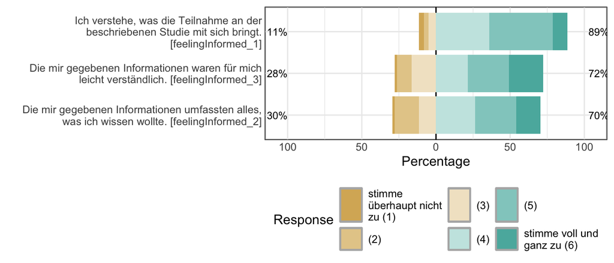

Likert plot of scale feelingInformed items

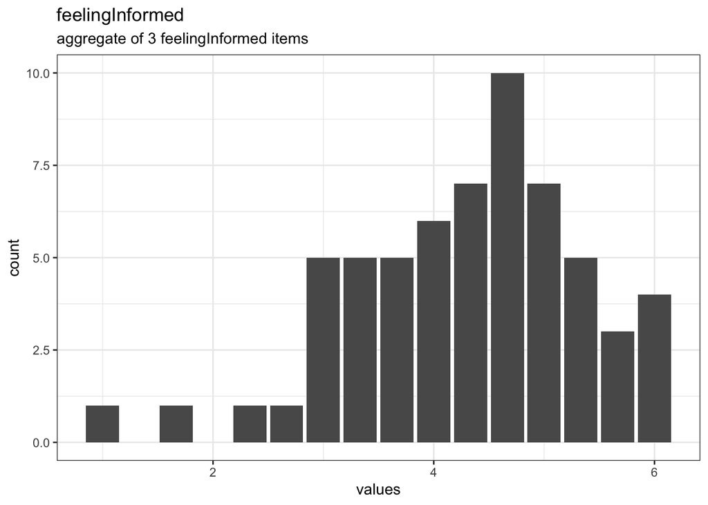

Distribution of scale feelingInformed

#### Reliability details

###### Reliability

###### 95% Confidence Interval

| lower | estimate | upper |
| --- | --- | --- |
| 0.6870988 | 0.7808152 | 0.8745317 |

|  | raw_alpha | std.alpha | G6(smc) | average_r | S/N | ase | mean | sd | median_r |
| --- | --- | --- | --- | --- | --- | --- | --- | --- | --- |
|  | 0.7808152 | 0.7885906 | 0.7157096 | 0.5542452 | 3.730157 | 0.0478145 | 4.284153 | 1.059063 | 0.5297746 |

###### Reliability if an item is dropped:

|  | raw_alpha | std.alpha | G6(smc) | average_r | S/N | alpha se | var.r | med.r |
| --- | --- | --- | --- | --- | --- | --- | --- | --- |
| feelingInformed_1 | 0.6925829 | 0.6926179 | 0.5297746 | 0.5297746 | 2.253280 | 0.0787130 | NA | 0.5297746 |
| feelingInformed_2 | 0.6790619 | 0.6911204 | 0.5280244 | 0.5280244 | 2.237508 | 0.0792184 | NA | 0.5280244 |
| feelingInformed_3 | 0.7399543 | 0.7538448 | 0.6049365 | 0.6049365 | 3.062478 | 0.0635942 | NA | 0.6049365 |

###### Item statistics

|  | n | raw.r | std.r | r.cor | r.drop | mean | sd |
| --- | --- | --- | --- | --- | --- | --- | --- |
| feelingInformed_1 | 61 | 0.8217416 | 0.8480793 | 0.7326099 | 0.6479877 | 4.409836 | 1.070468 |
| feelingInformed_2 | 61 | 0.8594146 | 0.8487752 | 0.7341252 | 0.6427886 | 4.114754 | 1.367460 |
| feelingInformed_3 | 61 | 0.8310017 | 0.8181944 | 0.6609867 | 0.5894609 | 4.327869 | 1.350572 |

###### Non missing response frequency for each item

|  | 1 | 2 | 3 | 4 | 5 | 6 | miss |
| --- | --- | --- | --- | --- | --- | --- | --- |
| feelingInformed_1 | 0.0327869 | 0.0327869 | 0.0491803 | 0.3606557 | 0.4262295 | 0.0983607 | 0 |
| feelingInformed_2 | 0.0163934 | 0.1639344 | 0.1147541 | 0.2622951 | 0.2786885 | 0.1639344 | 0 |
| feelingInformed_3 | 0.0163934 | 0.0983607 | 0.1639344 | 0.2131148 | 0.2786885 | 0.2295082 | 0 |

#### Summary statistics

| name | label | data_type | value_labels | n_missing | complete_rate | min | median | max | mean | sd | n_value_labels | hist |
| --- | --- | --- | --- | --- | --- | --- | --- | --- | --- | --- | --- | --- |
| feelingInformed_1 | Ich verstehe, was die Teilnahme an der beschriebenen Studie mit sich bringt. | haven_labelled | 1. stimme überhaupt nicht zu (1), 2. (2), 3. (3), 4. (4), 5. (5), 6. stimme voll und ganz zu (6) | 0 | 1 | 1 | 5 | 6 | 4.409836 | 1.070468 | 6 | ▁▁▁▁▇▁▇▂ |
| feelingInformed_2 | Die mir gegebenen Informationen umfassten alles, was ich wissen wollte. | haven_labelled | 1. stimme überhaupt nicht zu (1), 2. (2), 3. (3), 4. (4), 5. (5), 6. stimme voll und ganz zu (6) | 0 | 1 | 1 | 4 | 6 | 4.114754 | 1.367460 | 6 | ▁▅▁▃▇▁▇▅ |
| feelingInformed_3 | Die mir gegebenen Informationen waren für mich leicht verständlich. | haven_labelled | 1. stimme überhaupt nicht zu (1), 2. (2), 3. (3), 4. (4), 5. (5), 6. stimme voll und ganz zu (6) | 0 | 1 | 1 | 5 | 6 | 4.327869 | 1.350572 | 6 | ▁▃▁▅▆▁▇▆ |

### Scale: ReasonLowDwellTime

#### Overview

**Reliability**: Cronbach’s α [95% CI] = -0.19 [-0.66;0.27].

**Missing**: 0.

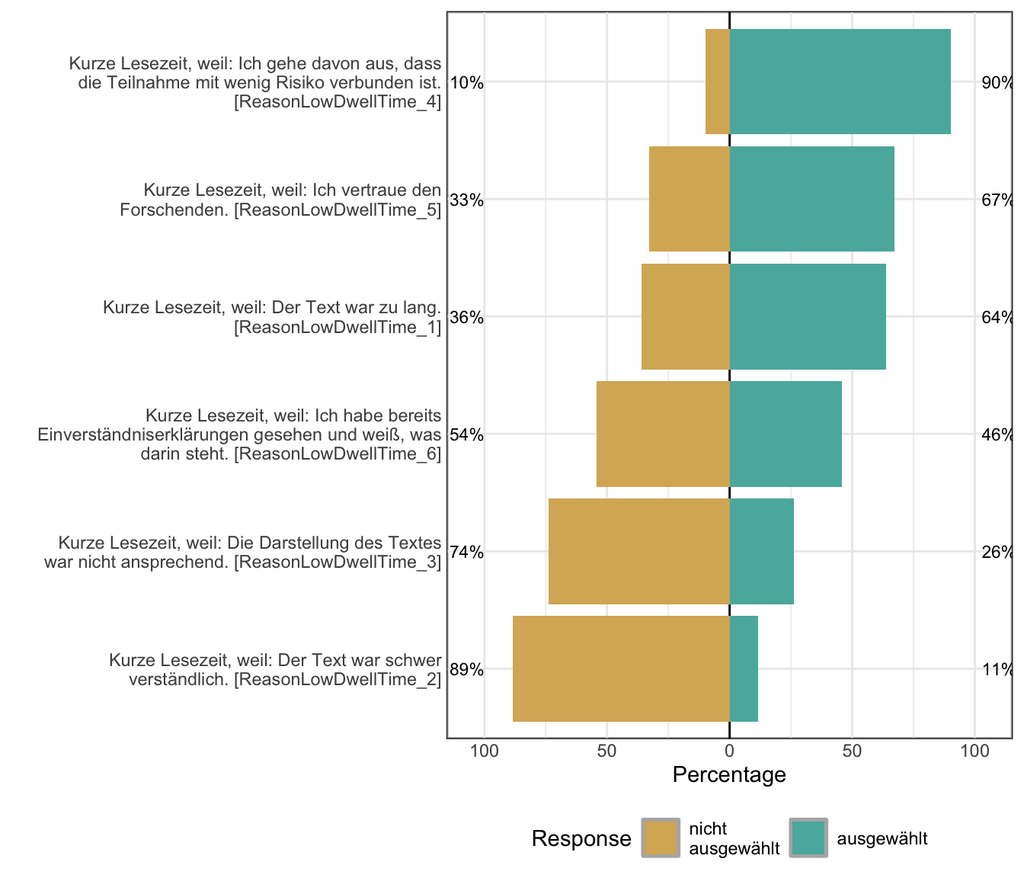

Likert plot of scale ReasonLowDwellTime items

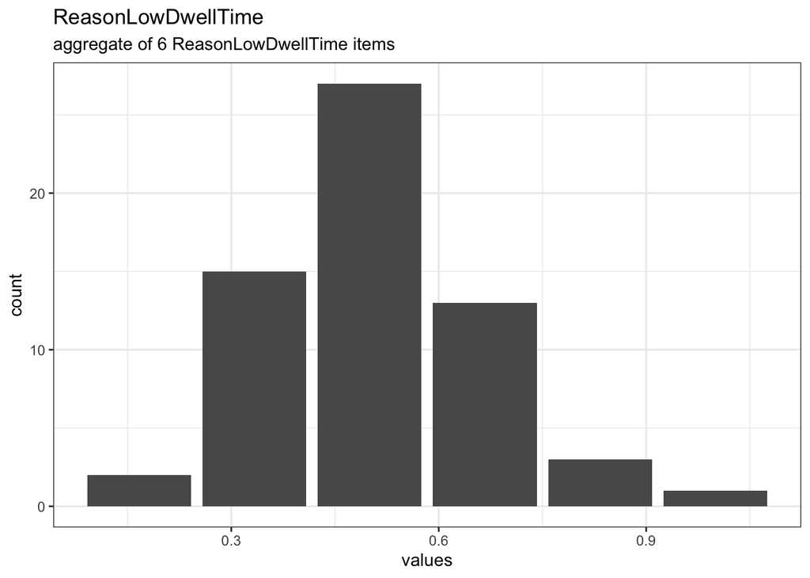

Distribution of scale ReasonLowDwellTime

#### Reliability details

###### Reliability

###### 95% Confidence Interval

| lower | estimate | upper |
| --- | --- | --- |
| -0.6594767 | -0.1944637 | 0.2705494 |

|  | raw_alpha | std.alpha | G6(smc) | average_r | S/N | ase | mean | sd | median_r |
| --- | --- | --- | --- | --- | --- | --- | --- | --- | --- |
|  | -0.1944637 | -0.0963475 | 0.0677694 | -0.0148645 | -0.0878804 | 0.2372516 | 0.5081967 | 0.1622362 | -0.0537961 |

###### Reliability if an item is dropped:

|  | raw_alpha | std.alpha | G6(smc) | average_r | S/N | alpha se | var.r | med.r |
| --- | --- | --- | --- | --- | --- | --- | --- | --- |
| ReasonLowDwellTime_1 | -0.2703221 | -0.2087793 | -0.0403757 | -0.0357798 | -0.1727191 | 0.2570969 | 0.0258587 | -0.0556189 |
| ReasonLowDwellTime_2 | -0.6332508 | -0.6099773 | -0.3830361 | -0.0819872 | -0.3788732 | 0.3297687 | 0.0102958 | -0.1339563 |
| ReasonLowDwellTime_3 | -0.1563562 | -0.0852751 | 0.0010174 | -0.0159658 | -0.0785746 | 0.2353468 | 0.0165910 | -0.0378965 |
| ReasonLowDwellTime_4 | -0.1118963 | 0.0231890 | 0.1541944 | 0.0047255 | 0.0237394 | 0.2284757 | 0.0345751 | -0.0397193 |
| ReasonLowDwellTime_5 | -0.0070489 | 0.0473836 | 0.1630644 | 0.0098501 | 0.0497405 | 0.2020508 | 0.0359631 | -0.0378965 |
| ReasonLowDwellTime_6 | 0.0875749 | 0.1338111 | 0.2184638 | 0.0299705 | 0.1544825 | 0.1842363 | 0.0327638 | 0.0180879 |

###### Item statistics

|  | n | raw.r | std.r | r.cor | r.drop | mean | sd |
| --- | --- | --- | --- | --- | --- | --- | --- |
| ReasonLowDwellTime_1 | 61 | 0.4979778 | 0.4815326 | 0.4406225 | 0.0006685 | 0.6393443 | 0.4841758 |
| ReasonLowDwellTime_2 | 61 | 0.6209894 | 0.6776003 | 1.3347671 | 0.3478821 | 0.1147541 | 0.3213700 |
| ReasonLowDwellTime_3 | 61 | 0.3942596 | 0.3974578 | 0.2728444 | -0.0666475 | 0.2622951 | 0.4435328 |
| ReasonLowDwellTime_4 | 61 | 0.1878882 | 0.3096604 | -0.3275963 | -0.1218566 | 0.9016393 | 0.3002731 |
| ReasonLowDwellTime_5 | 61 | 0.3249631 | 0.2879154 | -0.4020235 | -0.1681243 | 0.6721311 | 0.4733326 |
| ReasonLowDwellTime_6 | 61 | 0.2938395 | 0.2025402 | -0.7051032 | -0.2265551 | 0.4590164 | 0.5024530 |

###### Non missing response frequency for each item

|  | 0 | 1 | miss |
| --- | --- | --- | --- |
| ReasonLowDwellTime_1 | 0.3606557 | 0.6393443 | 0 |
| ReasonLowDwellTime_2 | 0.8852459 | 0.1147541 | 0 |
| ReasonLowDwellTime_3 | 0.7377049 | 0.2622951 | 0 |
| ReasonLowDwellTime_4 | 0.0983607 | 0.9016393 | 0 |
| ReasonLowDwellTime_5 | 0.3278689 | 0.6721311 | 0 |
| ReasonLowDwellTime_6 | 0.5409836 | 0.4590164 | 0 |

#### Summary statistics

| name | label | data_type | value_labels | n_missing | complete_rate | min | median | max | mean | sd | n_value_labels | hist |
| --- | --- | --- | --- | --- | --- | --- | --- | --- | --- | --- | --- | --- |
| ReasonLowDwellTime_1 | Kurze Lesezeit, weil: Der Text war zu lang. | haven_labelled | 0. nicht ausgewählt, 1. ausgewählt | 0 | 1 | 0 | 1 | 1 | 0.6393443 | 0.4841758 | 2 | ▅▁▁▁▁▁▁▇ |
| ReasonLowDwellTime_2 | Kurze Lesezeit, weil: Der Text war schwer verständlich. | haven_labelled | 0. nicht ausgewählt, 1. ausgewählt | 0 | 1 | 0 | 0 | 1 | 0.1147541 | 0.3213700 | 2 | ▇▁▁▁▁▁▁▁ |
| ReasonLowDwellTime_3 | Kurze Lesezeit, weil: Die Darstellung des Textes war nicht ansprechend. | haven_labelled | 0. nicht ausgewählt, 1. ausgewählt | 0 | 1 | 0 | 0 | 1 | 0.2622951 | 0.4435328 | 2 | ▇▁▁▁▁▁▁▃ |
| ReasonLowDwellTime_4 | Kurze Lesezeit, weil: Ich gehe davon aus, dass die Teilnahme mit wenig Risiko verbunden ist. | haven_labelled | 0. nicht ausgewählt, 1. ausgewählt | 0 | 1 | 0 | 1 | 1 | 0.9016393 | 0.3002731 | 2 | ▁▁▁▁▁▁▁▇ |
| ReasonLowDwellTime_5 | Kurze Lesezeit, weil: Ich vertraue den Forschenden. | haven_labelled | 0. nicht ausgewählt, 1. ausgewählt | 0 | 1 | 0 | 1 | 1 | 0.6721311 | 0.4733326 | 2 | ▃▁▁▁▁▁▁▇ |
| ReasonLowDwellTime_6 | Kurze Lesezeit, weil: Ich habe bereits Einverständniserklärungen gesehen und weiß, was darin steht. | haven_labelled | 0. nicht ausgewählt, 1. ausgewählt | 0 | 1 | 0 | 0 | 1 | 0.4590164 | 0.5024530 | 2 | ▇▁▁▁▁▁▁▇ |

## Missingness report

## Codebook table

| name | label | data_type | value_labels | scale_item_names | n_missing | complete_rate | min | median | max | mean | sd | n_value_labels | hist |
| --- | --- | --- | --- | --- | --- | --- | --- | --- | --- | --- | --- | --- | --- |
| condition | Experimentelle Bedingung | haven_labelled | 1. Niedrig/Fragebogen, 2. Niedrig/Interview, 3. Niedrig/Video, 4. Mittel/Fragebogen, 5. Mittel/Interview, 6. Mittel/Video, 7. Hoch/Fragebogen, 8. Hoch/Interview, 9. Hoch/Video | NA | 0 | 1 | 1 | 5 | 9 | 5.2622951 | 2.6514250 | 9 | ▇▃▅▅▃▅▃▆ |
| readEngageT1_01 | Ich habe den Text überflogen. | haven_labelled | 1. stimme überhaupt nicht zu (1), 2. (2), 3. (3), 4. (4), 5. (5), 6. stimme voll und ganz zu (6) | NA | 0 | 1 | 1 | 5 | 6 | 4.2950820 | 1.7353603 | 6 | ▂▂▁▂▃▁▅▇ |
| readEngageT1_02 | Ich habe überlegt, wie die Informationen in der Einverständniserklärung mit meiner eigenen Teilnahme an der Studie zusammenhängen. | haven_labelled | 1. stimme überhaupt nicht zu (1), 2. (2), 3. (3), 4. (4), 5. (5), 6. stimme voll und ganz zu (6) | NA | 0 | 1 | 1 | 2 | 6 | 2.6557377 | 1.4931538 | 6 | ▇▆▁▂▇▁▂▁ |
| readEngageT1_03 | Ich habe darüber nachgedacht, welche persönlichen Erfahrungen ich bisher bezüglich der Informationen in der Einverständniserklärung gemacht habe. | haven_labelled | 1. stimme überhaupt nicht zu (1), 2. (2), 3. (3), 4. (4), 5. (5), 6. stimme voll und ganz zu (6) | NA | 0 | 1 | 1 | 2 | 6 | 2.3770492 | 1.4278648 | 6 | ▇▆▁▃▂▁▂▁ |
| readEngageT1_05 | Ich habe mir Gedanken über die praktische Anwendung der Informationen in der Einverständniserklärung gemacht. | haven_labelled | 1. stimme überhaupt nicht zu (1), 2. (2), 3. (3), 4. (4), 5. (5), 6. stimme voll und ganz zu (6) | NA | 0 | 1 | 1 | 2 | 6 | 2.3114754 | 1.3606492 | 6 | ▇▅▁▃▃▁▂▁ |
| readEngageT1_06 | Ich muss gestehen, einige Stellen habe ich nicht sehr konzentriert gelesen. | haven_labelled | 1. stimme überhaupt nicht zu (1), 2. (2), 3. (3), 4. (4), 5. (5), 6. stimme voll und ganz zu (6) | NA | 0 | 1 | 1 | 6 | 6 | 5.2950820 | 1.2694390 | 6 | ▁▁▁▁▁▁▂▇ |
| readEngageT1_07 | Ich habe darüber nachgedacht, ob bzw. wie ich die Informationen im Einwilligungsformular auf meine Teilnahme beziehe. | haven_labelled | 1. stimme überhaupt nicht zu (1), 2. (2), 3. (3), 4. (4), 5. (5), 6. stimme voll und ganz zu (6) | NA | 0 | 1 | 1 | 2 | 6 | 2.4426230 | 1.3967175 | 6 | ▇▅▁▅▃▁▁▁ |
| readEngageT1_08 | Mit den Inhalten des Textes habe ich mich eher oberflächlich beschäftigt. | haven_labelled | 1. stimme überhaupt nicht zu (1), 2. (2), 3. (3), 4. (4), 5. (5), 6. stimme voll und ganz zu (6) | NA | 0 | 1 | 1 | 5 | 6 | 4.3278689 | 1.7099835 | 6 | ▂▃▁▂▅▁▃▇ |
| readEngageT1_09 | Ich muss zugeben, nicht alle von den vielen neuen Informationen habe ich behalten können. | haven_labelled | 1. stimme überhaupt nicht zu (1), 2. (2), 3. (3), 4. (4), 5. (5), 6. stimme voll und ganz zu (6) | NA | 0 | 1 | 1 | 5 | 6 | 5.0000000 | 1.2247449 | 6 | ▁▁▁▂▂▁▅▇ |
| readEngageT1_10 | Ich habe einige Parallelen zu Inhalten gesehen, mit denen ich mich schon einmal beschäftigt habe. | haven_labelled | 1. stimme überhaupt nicht zu (1), 2. (2), 3. (3), 4. (4), 5. (5), 6. stimme voll und ganz zu (6) | NA | 0 | 1 | 1 | 4 | 6 | 3.7540984 | 1.7668780 | 6 | ▆▂▁▃▅▁▇▅ |
| experience_participate | Ich habe Erfahrung mit der Teilnahme an wissenschaftlichen Studien, bei denen meine Daten erhoben und für Analysen verwendet wurden. | haven_labelled | 1. stimme überhaupt nicht zu (1), 2. (2), 3. (3), 4. (4), 5. (5), 6. stimme voll und ganz zu (6) | NA | 0 | 1 | 1 | 4 | 6 | 4.0163934 | 1.7653310 | 6 | ▅▂▁▃▅▁▇▇ |
| experience_plan | Ich habe Erfahrung in der Planung von wissenschaftlichen Studien, einschließlich des Umgangs mit und der Speicherung von Daten. | haven_labelled | 1. stimme überhaupt nicht zu (1), 2. (2), 3. (3), 4. (4), 5. (5), 6. stimme voll und ganz zu (6) | NA | 0 | 1 | 1 | 2 | 6 | 2.3114754 | 1.5442472 | 6 | ▇▂▁▃▂▁▂▁ |
| ReasonLowDwellTime_1 | Kurze Lesezeit, weil: Der Text war zu lang. | haven_labelled | 0. nicht ausgewählt, 1. ausgewählt | NA | 0 | 1 | 0 | 1 | 1 | 0.6393443 | 0.4841758 | 2 | ▅▁▁▁▁▁▁▇ |
| ReasonLowDwellTime_2 | Kurze Lesezeit, weil: Der Text war schwer verständlich. | haven_labelled | 0. nicht ausgewählt, 1. ausgewählt | NA | 0 | 1 | 0 | 0 | 1 | 0.1147541 | 0.3213700 | 2 | ▇▁▁▁▁▁▁▁ |
| ReasonLowDwellTime_3 | Kurze Lesezeit, weil: Die Darstellung des Textes war nicht ansprechend. | haven_labelled | 0. nicht ausgewählt, 1. ausgewählt | NA | 0 | 1 | 0 | 0 | 1 | 0.2622951 | 0.4435328 | 2 | ▇▁▁▁▁▁▁▃ |
| ReasonLowDwellTime_4 | Kurze Lesezeit, weil: Ich gehe davon aus, dass die Teilnahme mit wenig Risiko verbunden ist. | haven_labelled | 0. nicht ausgewählt, 1. ausgewählt | NA | 0 | 1 | 0 | 1 | 1 | 0.9016393 | 0.3002731 | 2 | ▁▁▁▁▁▁▁▇ |
| ReasonLowDwellTime_5 | Kurze Lesezeit, weil: Ich vertraue den Forschenden. | haven_labelled | 0. nicht ausgewählt, 1. ausgewählt | NA | 0 | 1 | 0 | 1 | 1 | 0.6721311 | 0.4733326 | 2 | ▃▁▁▁▁▁▁▇ |
| ReasonLowDwellTime_6 | Kurze Lesezeit, weil: Ich habe bereits Einverständniserklärungen gesehen und weiß, was darin steht. | haven_labelled | 0. nicht ausgewählt, 1. ausgewählt | NA | 0 | 1 | 0 | 0 | 1 | 0.4590164 | 0.5024530 | 2 | ▇▁▁▁▁▁▁▇ |
| participateT1_l1 | Ich nehme an der beschriebenen Studie teil. | haven_labelled | 1. stimme überhaupt nicht zu (1), 2. (2), 3. (3), 4. (4), 5. (5), 6. stimme voll und ganz zu (6) | NA | 0 | 1 | 1 | 3 | 6 | 3.4098361 | 1.4986333 | 6 | ▂▇▁▆▆▁▆▃ |
| sensitivityT1_l1 | Wie wohl fühlen Sie sich dabei, die Fragen zum Thema der Studie ehrlich zu beantworten? | haven_labelled | 1. sehr unwohl, 2. unwohl, 3. neutral, 4. wohl, 5. sehr wohl | NA | 0 | 1 | 2 | 4 | 5 | 3.7049180 | 0.9370924 | 5 | ▂▁▇▁▁▇▁▅ |
| benefits_1 | Die Teilnahme an der Studie könnte mir helfen, mich selbst oder meine Erfahrungen besser zu verstehen. | haven_labelled | 1. stimme überhaupt nicht zu (1), 2. (2), 3. (3), 4. (4), 5. (5), 6. stimme voll und ganz zu (6) | NA | 0 | 1 | 1 | 4 | 6 | 3.5573770 | 1.4778880 | 6 | ▂▅▁▃▇▁▃▂ |
| benefits_2 | Ich könnte für meine Teilnahme an der Studie Vorteile wie zum Beispiel Geld erhalten. | haven_labelled | 1. stimme überhaupt nicht zu (1), 2. (2), 3. (3), 4. (4), 5. (5), 6. stimme voll und ganz zu (6) | NA | 0 | 1 | 1 | 2 | 6 | 2.5901639 | 1.5745587 | 6 | ▇▆▁▁▆▁▂▁ |
| benefits_3 | Die Forschenden könnten meinen Ansichten und Erfahrungen mehr Aufmerksamkeit schenken, wenn ich an der Studie teilnehme. | haven_labelled | 1. stimme überhaupt nicht zu (1), 2. (2), 3. (3), 4. (4), 5. (5), 6. stimme voll und ganz zu (6) | NA | 0 | 1 | 1 | 4 | 6 | 3.7540984 | 1.5237644 | 6 | ▃▅▁▃▇▁▆▃ |
| benefits_4 | Die Teilnahme an der Studie ermöglicht es mir, eine aktivere Rolle dabei zu übernehmen, mich selbst zu verstehen und zu erforschen. | haven_labelled | 1. stimme überhaupt nicht zu (1), 2. (2), 3. (3), 4. (4), 5. (5), 6. stimme voll und ganz zu (6) | NA | 0 | 1 | 1 | 4 | 6 | 3.4098361 | 1.4762232 | 6 | ▃▅▁▃▇▁▃▂ |
| benefits_5 | Durch die Teilnahme an der Studie könnte ich neue Reflexionsmöglichkeiten oder Informationen erhalten, die mir sonst nicht zugänglich wären. | haven_labelled | 1. stimme überhaupt nicht zu (1), 2. (2), 3. (3), 4. (4), 5. (5), 6. stimme voll und ganz zu (6) | NA | 0 | 1 | 1 | 4 | 6 | 3.4918033 | 1.4676847 | 6 | ▃▅▁▂▇▁▇▁ |
| benefits_6 | Die Teilnahme an der Studie könnte Menschen in meinem näheren Umfeld helfen, meine Ansichten oder Erfahrungen besser zu verstehen. | haven_labelled | 1. stimme überhaupt nicht zu (1), 2. (2), 3. (3), 4. (4), 5. (5), 6. stimme voll und ganz zu (6) | NA | 0 | 1 | 1 | 2 | 6 | 2.3934426 | 1.3326501 | 6 | ▇▇▁▅▃▁▁▁ |
| benefits_7 | Meine Teilnahme an der Studie könnte dazu beitragen, dass andere Menschen in Zukunft von verbesserten Erkenntnissen profitieren. | haven_labelled | 1. stimme überhaupt nicht zu (1), 2. (2), 3. (3), 4. (4), 5. (5), 6. stimme voll und ganz zu (6) | NA | 0 | 1 | 1 | 5 | 6 | 4.3606557 | 1.3295712 | 6 | ▁▁▁▂▅▁▇▃ |
| benefits_8 | Die Teilnahme an der Studie könnte helfen, Angebote im Bildungs- und Sozialbereich in meiner Gemeinde oder meinem Land zu verbessern. | haven_labelled | 1. stimme überhaupt nicht zu (1), 2. (2), 3. (3), 4. (4), 5. (5), 6. stimme voll und ganz zu (6) | NA | 0 | 1 | 1 | 4 | 6 | 3.7213115 | 1.5180157 | 6 | ▃▅▁▅▇▁▇▃ |
| benefits_9 | Insgesamt denke ich, dass die Teilnahme an der Studie mehr Vorteile als Risiken hat. | haven_labelled | 1. stimme überhaupt nicht zu (1), 2. (2), 3. (3), 4. (4), 5. (5), 6. stimme voll und ganz zu (6) | NA | 0 | 1 | 1 | 4 | 6 | 4.3278689 | 1.4109254 | 6 | ▂▂▁▃▇▁▇▇ |
| feelingInformed_1 | Ich verstehe, was die Teilnahme an der beschriebenen Studie mit sich bringt. | haven_labelled | 1. stimme überhaupt nicht zu (1), 2. (2), 3. (3), 4. (4), 5. (5), 6. stimme voll und ganz zu (6) | NA | 0 | 1 | 1 | 5 | 6 | 4.4098361 | 1.0704680 | 6 | ▁▁▁▁▇▁▇▂ |
| feelingInformed_2 | Die mir gegebenen Informationen umfassten alles, was ich wissen wollte. | haven_labelled | 1. stimme überhaupt nicht zu (1), 2. (2), 3. (3), 4. (4), 5. (5), 6. stimme voll und ganz zu (6) | NA | 0 | 1 | 1 | 4 | 6 | 4.1147541 | 1.3674595 | 6 | ▁▅▁▃▇▁▇▅ |
| feelingInformed_3 | Die mir gegebenen Informationen waren für mich leicht verständlich. | haven_labelled | 1. stimme überhaupt nicht zu (1), 2. (2), 3. (3), 4. (4), 5. (5), 6. stimme voll und ganz zu (6) | NA | 0 | 1 | 1 | 5 | 6 | 4.3278689 | 1.3505716 | 6 | ▁▃▁▅▆▁▇▆ |
| EpistemicTrust_1R | Die Autor*innen der geplanten Studie erscheinen mir … unmoralisch-moralisch | haven_labelled | 1. [low trust] (1), 2. (2), 3. (3), 4. (4), 5. (5), 6. [high trust] (6) | NA | 0 | 1 | 2 | 5 | 6 | 4.9672131 | 1.0322663 | 6 | ▁▁▁▂▁▇▁▆ |
| EpistemicTrust_2R | Die Autor*innen der geplanten Studie erscheinen mir … unethisch-ethisch | haven_labelled | 1. [low trust] (1), 2. (2), 3. (3), 4. (4), 5. (5), 6. [high trust] (6) | NA | 0 | 1 | 2 | 5 | 6 | 4.9016393 | 1.1210846 | 6 | ▁▂▁▃▁▇▁▇ |
| EpistemicTrust_3R | Die Autor*innen der geplanten Studie erscheinen mir … unverantwortlich-verantwortungsvoll | haven_labelled | 1. [low trust] (1), 2. (2), 3. (3), 4. (4), 5. (5), 6. [high trust] (6) | NA | 0 | 1 | 2 | 5 | 6 | 5.0327869 | 1.1542272 | 6 | ▁▁▁▂▁▆▁▇ |
| EpistemicTrust_4R | Die Autor*innen der geplanten Studie erscheinen mir … rücksichtslos-rücksichtsvoll | haven_labelled | 1. [low trust] (1), 2. (2), 3. (3), 4. (4), 5. (5), 6. [high trust] (6) | NA | 0 | 1 | 2 | 5 | 6 | 4.7704918 | 1.2700845 | 6 | ▂▂▁▂▁▇▁▇ |
| RecallT1Q1_1c | Weitergabe der Daten: Nein, alle Daten werden gelöscht. | haven_labelled | 0. inkorrekt, 1. korrekt | NA | 0 | 1 | 0 | 1 | 1 | 0.7377049 | 0.4435328 | 2 | ▃▁▁▁▁▁▁▇ |
| RecallT1Q1_2c | Weitergabe der Daten: Ja, über die gesicherte Website der Universität ohne Zugangsbeschränkungen. | haven_labelled | 0. inkorrekt, 1. korrekt | NA | 0 | 1 | 0 | 1 | 1 | 0.9180328 | 0.2765913 | 2 | ▁▁▁▁▁▁▁▇ |
| RecallT1Q1_3c | Weitergabe der Daten: Ja, über ein vertrauenswürdiges Archiv ohne Zugangsbeschränkungen. | haven_labelled | 0. inkorrekt, 1. korrekt | NA | 0 | 1 | 0 | 0 | 1 | 0.2459016 | 0.4341942 | 2 | ▇▁▁▁▁▁▁▂ |
| RecallT1Q1_4c | Weitergabe der Daten: Ja, über ein Forschungsdatenzentrum mit eingeschränktem Zugang. | haven_labelled | 0. inkorrekt, 1. korrekt | NA | 0 | 1 | 0 | 1 | 1 | 0.5409836 | 0.5024530 | 2 | ▇▁▁▁▁▁▁▇ |
| RecallT1Q2_1c | Verantwortlich für Datenschutz: Die Leitung des Forschungsteams | haven_labelled | 0. inkorrekt, 1. korrekt | NA | 0 | 1 | 0 | 1 | 1 | 0.7704918 | 0.4240064 | 2 | ▂▁▁▁▁▁▁▇ |
| RecallT1Q2_2c | Verantwortlich für Datenschutz: Dr. Jürgen Schneider | haven_labelled | 0. inkorrekt, 1. korrekt | NA | 0 | 1 | 0 | 1 | 1 | 0.5081967 | 0.5040817 | 2 | ▇▁▁▁▁▁▁▇ |
| RecallT1Q2_3c | Verantwortlich für Datenschutz: DIPF \| Leibniz-Institut für Bildungsforschung und Bildungsinformation | haven_labelled | 0. inkorrekt, 1. korrekt | NA | 0 | 1 | 0 | 1 | 1 | 0.5409836 | 0.5024530 | 2 | ▇▁▁▁▁▁▁▇ |
| RecallT1Q2_4c | Verantwortlich für Datenschutz: Die/der Datenschutzbeauftragte des Instituts | haven_labelled | 0. inkorrekt, 1. korrekt | NA | 0 | 1 | 0 | 0 | 1 | 0.2295082 | 0.4240064 | 2 | ▇▁▁▁▁▁▁▂ |
| RecallT1Q3_1c | Anonymisierung: Ja, zum Zeitpunkt der Datenerhebung, keine Zuordnung möglich. | haven_labelled | 0. inkorrekt, 1. korrekt | NA | 0 | 1 | 0 | 1 | 1 | 0.9672131 | 0.1795562 | 2 | ▁▁▁▁▁▁▁▇ |
| RecallT1Q3_2c | Anonymisierung: Ja, aber erst nachdem die Daten analysiert wurden. | haven_labelled | 0. inkorrekt, 1. korrekt | NA | 0 | 1 | 1 | 1 | 1 | 1.0000000 | 0.0000000 | 2 | ▁▁▁▇▁▁▁▁ |
| RecallT1Q3_3c | Anonymisierung: Nein, Erfassung mit persönlichen Identifikatoren zur späteren Zuordnung. | haven_labelled | 0. inkorrekt, 1. korrekt | NA | 0 | 1 | 1 | 1 | 1 | 1.0000000 | 0.0000000 | 2 | ▁▁▁▇▁▁▁▁ |
| RecallT1Q3_4c | Anonymisierung: Nein, Pseudonymisierung, Re-Identifizierung bleibt möglich. | haven_labelled | 0. inkorrekt, 1. korrekt | NA | 0 | 1 | 0 | 1 | 1 | 0.9672131 | 0.1795562 | 2 | ▁▁▁▁▁▁▁▇ |
| RecallT1Q4_1c | Datenerhebung: Ich werde einen Fragebogen ausfüllen. | haven_labelled | 0. inkorrekt, 1. korrekt | NA | 0 | 1 | 0 | 1 | 1 | 0.8688525 | 0.3403630 | 2 | ▁▁▁▁▁▁▁▇ |
| RecallT1Q4_2c | Datenerhebung: Ich werde interviewt. | haven_labelled | 0. inkorrekt, 1. korrekt | NA | 0 | 1 | 1 | 1 | 1 | 1.0000000 | 0.0000000 | 2 | ▁▁▁▇▁▁▁▁ |
| RecallT1Q4_3c | Datenerhebung: Ich werde auf Video aufgezeichnet. | haven_labelled | 0. inkorrekt, 1. korrekt | NA | 0 | 1 | 1 | 1 | 1 | 1.0000000 | 0.0000000 | 2 | ▁▁▁▇▁▁▁▁ |
| RecallT1Q4_4c | Datenerhebung: Es wurden keine Informationen darüber gegeben, wie die Daten erhoben werden. | haven_labelled | 0. inkorrekt, 1. korrekt | NA | 0 | 1 | 0 | 1 | 1 | 0.8196721 | 0.3876509 | 2 | ▂▁▁▁▁▁▁▇ |
| RecallT1Q5_1c | Erhobene Daten: Interaktion mit der Befragung (z. B. aufgewendete Zeit, Aufmerksamkeit beim Lesen). | haven_labelled | 0. inkorrekt, 1. korrekt | NA | 0 | 1 | 0 | 1 | 1 | 0.6065574 | 0.4925677 | 2 | ▅▁▁▁▁▁▁▇ |
| RecallT1Q5_2c | Erhobene Daten: Verständnis und Eindrücke vom Studieninhalt. | haven_labelled | 0. inkorrekt, 1. korrekt | NA | 0 | 1 | 0 | 0 | 1 | 0.1311475 | 0.3403630 | 2 | ▇▁▁▁▁▁▁▁ |
| RecallT1Q5_3c | Erhobene Daten: Vorerfahrungen mit wissenschaftlicher Forschung und Teilnahmebereitschaft. | haven_labelled | 0. inkorrekt, 1. korrekt | NA | 0 | 1 | 0 | 0 | 1 | 0.3770492 | 0.4886694 | 2 | ▇▁▁▁▁▁▁▅ |
| RecallT1Q5_4c | Erhobene Daten: Sensitivität des Themas und Gefühl der Informiertheit. | haven_labelled | 0. inkorrekt, 1. korrekt | NA | 0 | 1 | 0 | 0 | 1 | 0.2459016 | 0.4341942 | 2 | ▇▁▁▁▁▁▁▂ |
| elaboration | 5 readEngageT1 items aggregated by rowMeans | numeric | NA | readEngageT1_02, readEngageT1_03, readEngageT1_05, readEngageT1_07, readEngageT1_10 | 0 | 1 | 1.00 | 2.60 | 6.00 | 2.7081967 | 1.1925177 | NA | ▇▆▆▂▁ |
| surface_reading | 4 readEngageT1_0 items aggregated by rowMeans | numeric | NA | readEngageT1_01, readEngageT1_06, readEngageT1_08, readEngageT1_09 | 0 | 1 | 1.00 | 5.00 | 6.00 | 4.7295082 | 1.1331143 | NA | ▁▁▅▃▇ |
| RecallT1 | 20 RecallT1Q items aggregated by rowMeans | numeric | NA | RecallT1Q1_1c, RecallT1Q1_2c, RecallT1Q1_3c, RecallT1Q1_4c, RecallT1Q2_1c, RecallT1Q2_2c, RecallT1Q2_3c, RecallT1Q2_4c, RecallT1Q3_1c, RecallT1Q3_2c, RecallT1Q3_3c, RecallT1Q3_4c, RecallT1Q4_1c, Recal… | 0 | 1 | 0.55 | 0.65 | 0.85 | 0.6737705 | 0.0710672 | NA | ▂▇▃▁▂ |
| benefits | aggregate of 9 benefits items | numeric | NA | benefits_1, benefits_2, benefits_3, benefits_4, benefits_5, benefits_6, benefits_7, benefits_8, benefits_9 | 0 | 1 | 1.22 | 3.56 | 5.44 | 3.5118397 | 0.9543659 | NA | ▂▃▇▇▃ |
| EpistemicTrust | aggregate of 4 EpistemicTrust items | numeric | NA | EpistemicTrust_1R, EpistemicTrust_2R, EpistemicTrust_3R, EpistemicTrust_4R | 0 | 1 | 2.00 | 5.00 | 6.00 | 4.9180328 | 1.0294834 | NA | ▁▁▂▇▇ |
| feelingInformed | aggregate of 3 feelingInformed items | numeric | NA | feelingInformed_1, feelingInformed_2, feelingInformed_3 | 0 | 1 | 1.00 | 4.33 | 6.00 | 4.2841530 | 1.0590633 | NA | ▁▂▅▇▃ |
| ReasonLowDwellTime | aggregate of 6 ReasonLowDwellTime items | numeric | NA | ReasonLowDwellTime_1, ReasonLowDwellTime_2, ReasonLowDwellTime_3, ReasonLowDwellTime_4, ReasonLowDwellTime_5, ReasonLowDwellTime_6 | 0 | 1 | 0.17 | 0.50 | 1.00 | 0.5081967 | 0.1622362 | NA | ▅▇▃▁▁ |

**JSON-LD metadata**